# Analisis Exploratorio de Datos

- Mostrar todo el código
- Ocultar todo el código
- Ver el código fuente

Primera entrega minería de datos

Autor/a

Carolina Díaz Alende,María Díaz Ramos,Rodrigo López Torres

Fecha de publicación

03 de noviembre de 2026

## 1 Introducción

La música lleva siglos formando parte de nuestras vidas, habiendo tenido un gran impacto en nuestra sociedad nunca nos hemos preguntado cómo nos habrá hecho cambiar la mentalidad. A continuación, realizaremos un trabajo sobre el vínculo que existe entre la música y la salud mental, para ello se han tomado cuatro enfermedades mentales (depresión, ansiedad, OCD e insomnio) y distintos géneros de música para obtener un conjunto de datos.

Como objetivo de este proyecto buscamos hacer un modelo que prediga la efectividad de la música en estos trastornos, es decir, si se ha observado alguna mejoría en el diagnóstico del paciente según sus gustos musicales. Para ello, hemos elaborado primeramente un análisis exploratorio en el que depuraremos y estudiaremos los datos.

## 2 Descripción y procedencia de los datos

La base de datos la hemos sacado de la web de kaggle https://www.kaggle.com/code/melissamonfared/multivariate-patterns-in-music-and-mental-health/input. Los datos proceden de encuestas de google forms, tras la difusión de la encuesta en redes sociales como discord o reddit, sin limitarlo a edad o localización. El formulario ha sido contestado por 736 personas, las cuales han dado su consentimiento al uso de los datos.

Variables de los datos en bruto antes de trabajar y depurar:

- Fecha: variable de fecha en la que se entregó el formulario.
- Edad: variable numérica de la edad de la persona que responde el formulario.
- Plataforma: variable categórica del servicio utilizado para escuchar música.
- Horas_pd: variable numérica sobre las horas que escuchan música diariamente.
- Trabajando: variable binaria de la escucha de música durante el trabajo.
- Instrumentista: variable binaria de si tocan algún instrumento.
- Músico: variable binaria de si la persona compone música.
- Genero_fav: variable categórica nominal sobre el género favorito de música.
- Explorador: variable binaria que describe si la persona suele probar música de artistas o géneros nuevos o si se queda en un mismo nicho.
- Extranjero: variable binaria que describe si la persona escucha música en idiomas no maternos.
- BPM: variable que describe las pulsaciones por minuto del género de música favorito escogido.
- f_genero: son variables categóricas ordinales que describen que tan frecuentemente escucha la persona el género de esa variable. Hay tantas variables como géneros ofrecidos dentro de la variable genero_fav.
- Ansiedad: variable categórica ordinal entre 0 y 10 que describe como uno se autopercibe el tener ansiedad.
- Depresion: variable categórica ordinal entre 0 y 10 que describe como uno se autopercibe el tener depresión.
- Insomnio: variable categórica ordinal entre 0 y 10 que describe como uno se autopercibe el tener insomnio.
- OCD: varibale categórica ordinal entre 0 y 10 que describe la autopercepción de tener OCD (transtorno obsesivo compulsivo).
- Efectos: variable categórica que describe si la música ha mejorado, empeorado o no tenido efecto en la persona.
- Permisos: variable binaria de si la persona da permiso para usar los datos.

## 3 Planteamiento inicial del EDA

Empezamos leyendo los datos y cargando todas las librerías que vamos a usar a lo largo del EDA.

**Código**

```r
library(dplyr)
library(caret)
library(tidyr)
library(mice)
library(forcats)
library(summarytools)
library(corrplot)
library(visdat) #para datos faltantes
library(naniar) ## gg_mis_var
library(FSelectorRcpp)
library(recipes) #arbol de imputación con guardado
datos <- read.csv("../data/musicData.csv",na.strings = c("", " ", "NA", "NaN"))
```

Antes de iniciar el análisis, modificamos los nombres de las variables al español y de forma simplificada para un seguimiento más sencillo.

**Código**

```r
colnames(datos) <- c("fecha","edad", "plataforma", "horas_pd", "trabajando", "instrumentista", "musico", "genero_fav", "explorador", "extranjero", "bpm", "f_clasica", "f_country", "f_edm", "f_folk", "f_gospel", "f_hiphop", "f_jazz", "f_kpop", "f_latin", "f_lofi", "f_metal","f_pop", "f_ryb", "f_rap", "f_rock", "f_vgm", "ansiedad", "depresion", "insomnio", "ocd","efectos","permisos")
```

**Esquema inicial de exploración**

Primero realizaremos un primer acercamiento general a los datos totales sin modificarlos, viendo cada variable para ver si detectamos problemas generales e información general de ellas.

Luego haremos las modificaciones prepartición que no afecten a nuestro estudio y que no estén basadas en sesgos. Realizaremos la partición y empezaremos a analizar las variables con las que podamos tener dudas para ver su validez en relación a nuestra variable objetivo.

Una vez resueltas las sospechas con las variables dudosas, procederemos a analizar los datos faltantes de las variables y realizaremos una imputación por árbol de regresión, para el que guardaremos la receta para usar posteriormente en el validation.

Realizaremos un análisis sobre nuestro conjunto train imputado en busca de sacar más información y de responder nuestras preguntas de partida. Buscando encontrar estrategias para proseguir nuestro proyecto, como clusters, ingeniería de variables, etc.

## 4 Preguntas de partida

Formulamos las preguntas que inicialmente queremos estudiar a partir de nuestros datos.

¿Existe alguna relación entre grupos de edades y el padecimiento de alguna enfermedad mental?¿Predomina alguna edad con algún tipo de enfermedad mental?

¿Qué género de música es el más habitual? ¿Y el que menos?

¿Existe algún género musical que tenga efecto positivo en alguna de las enfermedades mentales? ¿Cuáles son los géneros más/menos escuchados entre la gente con depresión/ansiedad/ocd/insomnia?

¿Es relevante saber la plataforma con la que escuchan música de cara a nuestra variable respuesta?

¿Que tan relevante es el género favorito?

## 5 Proceso de exploración

Tras haber renombrado las variables procedemos a realizar el proceso de exploración de nuestros datos.

Empezamos viendo la dimensión de nuestros datos y su encabezado.

**Código**

```r
dim(datos)
```

```
[1] 736  33
```

**Código**

```r
head(datos)
```

```
               fecha edad    plataforma horas_pd trabajando instrumentista
1 8/27/2022 19:29:02   18       Spotify      3.0        Yes            Yes
2 8/27/2022 19:57:31   63       Pandora      1.5        Yes             No
3 8/27/2022 21:28:18   18       Spotify      4.0         No             No
4 8/27/2022 21:40:40   61 YouTube Music      2.5        Yes             No
5 8/27/2022 21:54:47   18       Spotify      4.0        Yes             No
6 8/27/2022 21:56:50   18       Spotify      5.0        Yes            Yes
  musico       genero_fav explorador extranjero bpm f_clasica f_country
1    Yes            Latin        Yes        Yes 156    Rarely     Never
2     No             Rock        Yes         No 119 Sometimes     Never
3     No Video game music         No        Yes 132     Never     Never
4    Yes             Jazz        Yes        Yes  84 Sometimes     Never
5     No              R&B        Yes         No 107     Never     Never
6    Yes             Jazz        Yes        Yes  86    Rarely Sometimes
            f_edm f_folk  f_gospel        f_hiphop          f_jazz
```

[output cut: 27 more lines]

Podemos observar que tenemos 736 entradas, que representan la respuesta al formulario de 736 personas, con un total de 33 variables (descritas previamente). Vamos a entrar en detalle para conocer mejor nuestros datos.

**Código**

```r
str(datos)
```

```
'data.frame':   736 obs. of  33 variables:
 $ fecha         : chr  "8/27/2022 19:29:02" "8/27/2022 19:57:31" "8/27/2022 21:28:18" "8/27/2022 21:40:40" ...
 $ edad          : int  18 63 18 61 18 18 18 21 19 18 ...
 $ plataforma    : chr  "Spotify" "Pandora" "Spotify" "YouTube Music" ...
 $ horas_pd      : num  3 1.5 4 2.5 4 5 3 1 6 1 ...
 $ trabajando    : chr  "Yes" "Yes" "No" "Yes" ...
 $ instrumentista: chr  "Yes" "No" "No" "No" ...
 $ musico        : chr  "Yes" "No" "No" "Yes" ...
 $ genero_fav    : chr  "Latin" "Rock" "Video game music" "Jazz" ...
 $ explorador    : chr  "Yes" "Yes" "No" "Yes" ...
 $ extranjero    : chr  "Yes" "No" "Yes" "Yes" ...
 $ bpm           : int  156 119 132 84 107 86 66 95 94 155 ...
 $ f_clasica     : chr  "Rarely" "Sometimes" "Never" "Sometimes" ...
 $ f_country     : chr  "Never" "Never" "Never" "Never" ...
 $ f_edm         : chr  "Rarely" "Never" "Very frequently" "Never" ...
```

[output cut: 19 more lines]

Podemos observar que hay unos vacíos en los datos, que debemos investigar. Ejemplo de ello en el str, es en efectos, que tenemos las dos primeras entradas vacias (NA).

Vamos a ir revisando las variables una a una.

**Fecha:** Observamos que cada persona tiene una fecha distinta. Teniendo en cuenta el contexto de nuestra investigación, la fecha de entrega del formulario no va a tener relevancia en los resultados, por lo que podemos concluir que esta variable es una candidata a ser eliminada, ya que no aportará a nuestra variable respuesta.

**Código**

```r
table(datos$fecha, useNA = 'always')
```

```
10/11/2022 15:46:46 10/14/2022 18:01:12 10/14/2022 20:42:26 10/15/2022 14:00:55
                  1                   1                   1                   1
  10/2/2022 7:52:02 10/22/2022 15:20:29 10/23/2022 20:50:27 10/26/2022 19:45:54
                  1                   1                   1                   1
 10/3/2022 10:00:01  10/3/2022 10:25:46  10/3/2022 10:53:28  10/3/2022 11:30:10
                  1                   1                   1                   1
 10/3/2022 13:01:06  10/3/2022 13:47:14  10/3/2022 15:38:19  10/3/2022 16:43:32
                  1                   1                   1                   1
 10/3/2022 20:03:57   10/3/2022 9:30:19 10/30/2022 13:13:32 10/30/2022 13:15:26
                  1                   1                   1                   1
10/30/2022 14:37:28  10/30/2022 7:24:08   10/4/2022 0:48:34  10/4/2022 14:50:28
                  1                   1                   1                   1
 10/4/2022 19:33:42  10/4/2022 19:43:11   10/4/2022 4:50:49   10/4/2022 8:12:33
                  1                   1                   1                   1
  10/4/2022 8:53:39  10/5/2022 12:30:23   10/5/2022 8:58:16   10/6/2022 3:35:11
                  1                   1                   1                   1
  10/6/2022 9:17:46  10/9/2022 22:15:59  11/1/2022 22:26:42  11/3/2022 23:24:38
                  1                   1                   1                   1
 11/4/2022 17:31:47   11/9/2022 1:55:20  8/27/2022 19:29:02  8/27/2022 19:57:31
                  1                   1                   1                   1
 8/27/2022 21:28:18  8/27/2022 21:40:40  8/27/2022 21:54:47  8/27/2022 21:56:50
                  1                   1                   1                   1
 8/27/2022 22:00:29  8/27/2022 22:18:59  8/27/2022 22:33:05  8/27/2022 22:44:03
                  1                   1                   1                   1
 8/27/2022 22:51:15  8/27/2022 23:00:32  8/27/2022 23:04:00  8/27/2022 23:12:03
                  1                   1                   1                   1
 8/27/2022 23:16:06  8/27/2022 23:19:52  8/27/2022 23:39:41  8/27/2022 23:39:49
                  1                   1                   1                   1
 8/27/2022 23:40:55  8/27/2022 23:41:36  8/27/2022 23:43:06   8/28/2022 0:28:02
                  1                   1                   1                   1
  8/28/2022 1:39:02  8/28/2022 10:30:22  8/28/2022 10:38:05  8/28/2022 10:54:30
                  1                   1                   1                   1
 8/28/2022 10:59:53  8/28/2022 11:08:51  8/28/2022 11:13:25  8/28/2022 11:25:49
                  1                   1                   1                   1
 8/28/2022 11:27:15  8/28/2022 11:36:35  8/28/2022 11:39:21  8/28/2022 11:50:31
                  1                   1                   1                   1
 8/28/2022 11:54:45  8/28/2022 11:55:54  8/28/2022 11:58:48  8/28/2022 12:08:29
                  1                   1                   1                   1
 8/28/2022 12:12:35  8/28/2022 12:15:02  8/28/2022 12:23:52  8/28/2022 12:30:08
                  1                   1                   1                   1
```

[output cut: 313 more lines]

```
                  1                   1                   1                   1
  9/6/2022 11:15:37   9/6/2022 11:19:55   9/6/2022 12:36:19   9/6/2022 13:26:11
                  1                   1                   1                   1
  9/6/2022 14:43:07   9/6/2022 15:53:44   9/6/2022 19:27:55    9/6/2022 9:40:57
                  1                   1                   1                   1
  9/7/2022 12:32:12   9/7/2022 14:17:21   9/7/2022 19:43:58   9/7/2022 21:19:11
                  1                   1                   1                   1
   9/7/2022 9:16:47   9/8/2022 15:06:09   9/8/2022 16:56:15   9/8/2022 18:12:17
                  1                   1                   1                   1
  9/8/2022 18:14:01   9/8/2022 19:16:43   9/8/2022 21:30:13   9/8/2022 23:40:30
                  1                   1                   1                   1
  9/9/2022 11:15:23   9/9/2022 11:25:57   9/9/2022 18:44:18   9/9/2022 22:31:31
                  1                   1                   1                   1
  9/9/2022 23:34:31    9/9/2022 7:19:08    9/9/2022 7:48:44                <NA>
                  1                   1                   1                   0
```

**Variable edad:** En edad vemos que tenemos un valor N/A, por lo demás tenemos diversas edades comprendidas entre 10 y 89 años, con una media de 25,2 años y una mediana de 21 años.

**Código**

```r
table(datos$edad, useNA = 'always')
```

```
  10   12   13   14   15   16   17   18   19   20   21   22   23   24   25   26
   1    3    8   17   21   44   59   85   61   40   52   39   37   20   22   22
  27   28   29   30   31   32   33   34   35   36   37   38   39   40   41   42
  18   13   13   11   13   16    8    8    7    7    5    6    1    5    4    6
  43   44   46   48   49   50   51   53   54   55   56   57   58   59   60   61
   4    3    1    2    5    1    1    3    2    1    5    3    3    2    6    2
  63   64   65   67   68   69   70   71   72   73   74   80   89 <NA>
   3    3    1    3    1    1    1    1    1    1    1    1    1    1
```

**Código**

```r
media_edad <- mean(datos$edad, na.rm = TRUE)
mediana_edad<- median(datos$edad, na.rm = TRUE)
print(media_edad)
```

```
[1] 25.2068
```

**Código**

```r
print(mediana_edad)
```

```
[1] 21
```

**Código**

```r
edad_maxima <- max(datos$edad, na.rm = TRUE)
print(edad_maxima)
```

```
[1] 89
```

**Código**

```r
edad_min <- min(datos$edad, na.rm = TRUE)
print(edad_min)
```

```
[1] 10
```

**Variable plataforma:** vemos que hay un valor no rellenado NA. Por otro lado, podemos ver que esta varible es de tipo categórico y cuyas entradas son del tipo character, para evitarnos problemas, vamos a transformarla a tipo factor junto con todas las demás que sean de tipo char.

**Código**

```r
table(datos$plataforma, useNA = 'always')
```

```
                      Apple Music I do not use a streaming service.
                               51                                71
          Other streaming service                           Pandora
                               50                                11
                          Spotify                     YouTube Music
                              458                                94
                             <NA>
                                1
```

Pasamos así todas nuestras variables que tengan caracteres a factor nominal para distinguir los diferentes grupos de cada variable. En particular, las columnas que contengan las frecuencias de escucha de cada género musical pasarán a ser ordinales para poder distinguir la jerarquía de los valores tomados.

**Código**

```r
datos_factor <- datos %>% mutate_if(is.character, as.factor)  %>%
    mutate(across(contains("f_"),
    ~ factor(.x, levels = c("Never", "Rarely", "Sometimes", "Very frequently"), ordered = TRUE)))
```

**Variable horas_pd:** Tenemos diversas cantidades de horas comprendidas entre 0 y 24 horas, con una media de 3,57 horas y una mediana de 3 horas.

**Código**

```r
table(datos_factor$horas_pd, useNA = 'always')
```

```
   0  0.1 0.25  0.5  0.7    1  1.5    2  2.5    3    4  4.5    5    6    7    8
   6    1    3   20    1  117   17  173    6  120   83    1   54   47   15   29
   9   10   11   12   13   14   15   16   18   20   24 <NA>
   3   20    1    9    1    1    2    1    1    1    3    0
```

**Código**

```r
media_horas <- mean(datos_factor$horas_pd, na.rm = TRUE)
mediana_horas<- median(datos_factor$horas_pd, na.rm = TRUE)
print(media_horas)
```

```
[1] 3.572758
```

**Código**

```r
print(mediana_horas)
```

```
[1] 3
```

**Código**

```r
horas_maxima <- max(datos_factor$horas_pd, na.rm = TRUE)
print(horas_maxima)
```

```
[1] 24
```

**Código**

```r
horas_min <- min(datos_factor$horas_pd, na.rm = TRUE)
print(horas_min)
```

```
[1] 0
```

**Variables trabajando, instrumentista, músico, explorador y extranjero:** Vemos que en 4 de estas 5 variables que se pueden tratar como binarias al ser si o no, tenemos algunos datos faltantes como NA.

**Código**

```r
print("Variable trabajando:")
```

```
[1] "Variable trabajando:"
```

**Código**

```r
table(datos_factor$trabajando, useNA = 'always')
```

```
  No  Yes <NA>
 154  579    3
```

**Código**

```r
print("Variable instrumentista:")
```

```
[1] "Variable instrumentista:"
```

**Código**

```r
table(datos_factor$instrumentista, useNA = 'always')
```

```
  No  Yes <NA>
 497  235    4
```

**Código**

```r
print("Variable músico:")
```

```
[1] "Variable músico:"
```

**Código**

```r
table(datos_factor$musico, useNA = 'always')
```

```
  No  Yes <NA>
 609  126    1
```

**Código**

```r
print("Variable explorador:")
```

```
[1] "Variable explorador:"
```

**Código**

```r
table(datos_factor$explorador, useNA = 'always')
```

```
  No  Yes <NA>
 211  525    0
```

**Código**

```r
print("Variable extranjero:")
```

```
[1] "Variable extranjero:"
```

**Código**

```r
table(datos_factor$extranjero, useNA = 'always')
```

```
  No  Yes <NA>
 328  404    4
```

**Variable genero_fav:** Vemos que tenemos 16 opciones para esta variable categórica, pero nos llama la atención que hay ciertos géneros de música que son el favorito de poca gente, lo que puede hacer que al dividir la muestra en tres para hacer el estudio, no nos aporten significativamente, por lo que posteriormente agruparemos los géneros que tengan menos de 20 elegidos en una categoría que llamaremos “Otros géneros”.

**Código**

```r
table(datos_factor$genero_fav, useNA = 'always')
```

```
       Classical          Country              EDM             Folk
              53               25               37               30
          Gospel          Hip hop             Jazz            K pop
               6               35               20               26
           Latin             Lofi            Metal              Pop
               3               10               88              114
             R&B              Rap             Rock Video game music
              35               22              188               44
            <NA>
               0
```

**Variable bpm:** Tenemos que los bpm van comprendidos desde 0 hasta 999999999, con media 1589948 y mediana 120. Esta diferencia entre la media y la mediana se debe a que tenemos valores muy bajos entre 0 y 100 y luego algunos valores más altos como 624 o 999999999, lo que hace que al haber tal diferencia de magnitud esos valores más separados tengan mayor carga en la media y quizá se deba a algún error en los datos, que tocará analizar. Además, por el contexto de nuestros datos debemos plantearnos la relevancia de esta variable para nuestro estudio ya que no tenemos claro que sea relevante.

También llama la atención que tenemos muchos datos faltantes en bpm, lo que aumenta nuestra desconfianza en esta variable. Posteriormente continuaremos el análisis sobre esta variable para determinar si la mantenemos o eliminamos de nuestro estudio.

Aun así, al ser solo la primera aproximación a las variables, dejaremos el análisis en profundidad de esta variable para más adelante.

**Código**

```r
table(datos_factor$bpm, useNA = 'always')
```

```
        0         4         8        20        40        52        55        56
        3         1         1         1         1         1         2         1
       60        61        62        63        66        68        70        72
        2         1         1         1         3         1         3         5
       73        75        76        77        78        79        80        81
        2         3         3         5         3         3        11         4
       82        84        85        86        87        88        89        90
        1         5         9         4         3         2         6        11
       91        92        93        94        95        96        97        98
        5         7         7         4        10         4         6         5
       99       100       101       102       103       104       105       106
        4        11         4         2         6         3        15         1
      107       108       109       110       111       112       113       114
        5         7         5        16         2         8         8         6
      115       116       117       118       119       120       121       122
```

[output cut: 19 more lines]

**Código**

```r
media_bpm <- mean(datos_factor$bpm, na.rm = TRUE)
mediana_bpm<- median(datos_factor$bpm, na.rm = TRUE)
cat("La media es", media_bpm, "\n")
```

```
La media es 1589948
```

**Código**

```r
cat("La mediana es",mediana_bpm, "\n")
```

```
La mediana es 120
```

**Código**

```r
bpm_maxima <- max(datos_factor$bpm, na.rm = TRUE)
cat("El máximo es",bpm_maxima,"\n")
```

```
El máximo es 999999999
```

**Código**

```r
bpm_min <- min(datos_factor$bpm, na.rm = TRUE)
cat("El mínimo es",bpm_min,"\n")
```

```
El mínimo es 0
```

**Variables frecuencias:** Tenemos este conjunto de variables categóricas ordinales y tras ver los tables parece que no tenemos huecos faltantes y está todo en orden.

**Código**

```r
print("Variable f_clasica:")
```

```
[1] "Variable f_clasica:"
```

**Código**

```r
table(datos_factor$f_clasica, useNA = 'always')
```

```
          Never          Rarely       Sometimes Very frequently            <NA>
            169             259             200             108               0
```

**Código**

```r
print("Variable f_country:")
```

```
[1] "Variable f_country:"
```

**Código**

```r
table(datos_factor$f_country, useNA = 'always')
```

```
          Never          Rarely       Sometimes Very frequently            <NA>
            343             233             111              49               0
```

**Código**

```r
print("Variable f_edm:")
```

```
[1] "Variable f_edm:"
```

**Código**

```r
table(datos_factor$f_edm, useNA = 'always')
```

```
          Never          Rarely       Sometimes Very frequently            <NA>
            307             194             146              89               0
```

**Código**

```r
print("Variable f_folk")
```

```
[1] "Variable f_folk"
```

**Código**

```r
table(datos_factor$f_folk, useNA = 'always')
```

```
          Never          Rarely       Sometimes Very frequently            <NA>
            292             221             145              78               0
```

**Código**

```r
print("Variable f_gospel:")
```

```
[1] "Variable f_gospel:"
```

**Código**

```r
table(datos_factor$f_gospel, useNA = 'always')
```

```
          Never          Rarely       Sometimes Very frequently            <NA>
            535             135              52              14               0
```

**Código**

```r
print("Variable f_hiphop:")
```

```
[1] "Variable f_hiphop:"
```

**Código**

```r
table(datos_factor$f_hiphop, useNA = 'always')
```

```
          Never          Rarely       Sometimes Very frequently            <NA>
            181             214             218             123               0
```

**Código**

```r
print("Variable f_jazz:")
```

```
[1] "Variable f_jazz:"
```

**Código**

```r
table(datos_factor$f_jazz, useNA = 'always')
```

```
          Never          Rarely       Sometimes Very frequently            <NA>
            261             247             175              53               0
```

**Código**

```r
print("Variable f_kpop:")
```

```
[1] "Variable f_kpop:"
```

**Código**

```r
table(datos_factor$f_kpop, useNA = 'always')
```

```
          Never          Rarely       Sometimes Very frequently            <NA>
            416             176              67              77               0
```

**Código**

```r
print("Variable f_latin:")
```

```
[1] "Variable f_latin:"
```

**Código**

```r
table(datos_factor$f_latin, useNA = 'always')
```

```
          Never          Rarely       Sometimes Very frequently            <NA>
            443             172              88              33               0
```

**Código**

```r
print("Variable f_lofi:")
```

```
[1] "Variable f_lofi:"
```

**Código**

```r
table(datos_factor$f_lofi, useNA = 'always')
```

```
          Never          Rarely       Sometimes Very frequently            <NA>
            280             211             160              85               0
```

**Código**

```r
print("Variable f_metal:")
```

```
[1] "Variable f_metal:"
```

**Código**

```r
table(datos_factor$f_metal, useNA = 'always')
```

```
          Never          Rarely       Sometimes Very frequently            <NA>
            264             192             134             146               0
```

**Código**

```r
print("Variable f_pop:")
```

```
[1] "Variable f_pop:"
```

**Código**

```r
table(datos_factor$f_pop, useNA = 'always')
```

```
          Never          Rarely       Sometimes Very frequently            <NA>
             56             142             261             277               0
```

**Código**

```r
print("Variable f_ryb:")
```

```
[1] "Variable f_ryb:"
```

**Código**

```r
table(datos_factor$f_ryb, useNA = 'always')
```

```
          Never          Rarely       Sometimes Very frequently            <NA>
            225             211             184             116               0
```

**Código**

```r
print("Variable f_rap:")
```

```
[1] "Variable f_rap:"
```

**Código**

```r
table(datos_factor$f_rap, useNA = 'always')
```

```
          Never          Rarely       Sometimes Very frequently            <NA>
            200             215             195             126               0
```

**Código**

```r
print("Variable f_rock:")
```

```
[1] "Variable f_rock:"
```

**Código**

```r
table(datos_factor$f_rock, useNA = 'always')
```

```
          Never          Rarely       Sometimes Very frequently            <NA>
             91              96             219             330               0
```

**Código**

```r
print("Variable f_vgm:")
```

```
[1] "Variable f_vgm:"
```

**Código**

```r
table(datos_factor$f_vgm, useNA = 'always')
```

```
          Never          Rarely       Sometimes Very frequently            <NA>
            236             197             186             117               0
```

Continuamos ahora analizando las variables objetivos: ansiedad, depresión, insomnio y ocd.

**Variable ansiedad:**

**Código**

```r
table(datos_factor$ansiedad, useNA = 'always')
```

```
   0    1    2    3    4    5    6    7  7.5    8    9   10 <NA>
  35   29   44   69   56   59   83  122    1  115   56   67    0
```

**Código**

```r
media_ansiedad <- mean(datos_factor$ansiedad, na.rm = TRUE)
mediana_ansiedad<- median(datos_factor$ansiedad, na.rm = TRUE)
cat("La media es", media_ansiedad, "\n")
```

```
La media es 5.837636
```

**Código**

```r
cat("La mediana es",mediana_ansiedad, "\n")
```

```
La mediana es 6
```

**Variable depresión:**

**Código**

```r
table(datos_factor$depresion, useNA = 'always')
```

```
   0    1    2    3  3.5    4    5    6    7    8    9   10 <NA>
  84   40   93   59    2   58   56   88   96   77   38   45    0
```

**Código**

```r
media_depresion <- mean(datos_factor$depresion, na.rm = TRUE)
mediana_depresion<- median(datos_factor$depresion, na.rm = TRUE)
cat("La media es", media_depresion, "\n")
```

```
La media es 4.796196
```

**Código**

```r
cat("La mediana es",mediana_depresion, "\n")
```

```
La mediana es 5
```

**Variable insomnio:**

**Código**

```r
table(datos_factor$insomnio, useNA = 'always')
```

```
   0    1    2    3  3.5    4    5    6    7    8    9   10 <NA>
 149   82   88   68    1   59   58   62   59   49   27   34    0
```

**Código**

```r
media_insomnio <- mean(datos_factor$insomnio, na.rm = TRUE)
mediana_insomnio<- median(datos_factor$insomnio, na.rm = TRUE)
cat("La media es", media_insomnio, "\n")
```

```
La media es 3.738451
```

**Código**

```r
cat("La mediana es",mediana_insomnio, "\n")
```

```
La mediana es 3
```

**Variable ocd:**

**Código**

```r
table(datos_factor$ocd, useNA = 'always')
```

```
   0    1    2    3    4    5  5.5    6    7    8  8.5    9   10 <NA>
 248   95   96   64   48   54    1   33   34   28    1   14   20    0
```

**Código**

```r
media_ocd <- mean(datos_factor$ocd, na.rm = TRUE)
mediana_ocd<- median(datos_factor$ocd, na.rm = TRUE)
cat("La media es", media_ocd, "\n")
```

```
La media es 2.637228
```

**Código**

```r
cat("La mediana es",mediana_ocd, "\n")
```

```
La mediana es 2
```

**Variable efectos:** Como vimos al inicio en esta variable tenemos 8 NA, que nos tocará ver como tratar más adelante.

**Código**

```r
table(datos_factor$efectos, useNA = 'always')
```

```
  Improve No effect    Worsen      <NA>
      542       169        17         8
```

**Variable permisos:** Esta variable al representar el permiso de usar los datos del formulario, fuerza a que todas las respuestas sean que afirmativas, por lo que procederemos a eliminarla posteriormente, pues es una clara candidata a ser eliminada, pues no aportará tenerla en cuenta para nuestro proyecto.

**Código**

```r
table(datos_factor$permisos, useNA = 'always')
```

```
I understand.          <NA>
          736             0
```

Ya hemos analizado nuestro conjunto de datos por encima, aunque tenemos algunas dudas sobre algunas variables candidatas a ser eliminadas, hay dos que son claras y que podemos eliminar antes de la partición de nuestros datos. Estas son la fecha y el consentimiento. También agruparemos algunas de nuestras categorias de género favorito en otros géneros.

**Código**

```r
#Agrupamos las categorías
datos_factor$genero_fav<-fct_collapse(datos_factor$genero_fav,"Otros géneros"=c("Gospel","Latin", "Lofi"))
table(datos_factor$genero_fav,useNA = 'always')
```

```
       Classical          Country              EDM             Folk
              53               25               37               30
   Otros géneros          Hip hop             Jazz            K pop
              19               35               20               26
           Metal              Pop              R&B              Rap
              88              114               35               22
            Rock Video game music             <NA>
             188               44                0
```

**Código**

```r
head(datos_factor)
```

```
               fecha edad    plataforma horas_pd trabajando instrumentista
1 8/27/2022 19:29:02   18       Spotify      3.0        Yes            Yes
2 8/27/2022 19:57:31   63       Pandora      1.5        Yes             No
3 8/27/2022 21:28:18   18       Spotify      4.0         No             No
4 8/27/2022 21:40:40   61 YouTube Music      2.5        Yes             No
5 8/27/2022 21:54:47   18       Spotify      4.0        Yes             No
6 8/27/2022 21:56:50   18       Spotify      5.0        Yes            Yes
  musico       genero_fav explorador extranjero bpm f_clasica f_country
1    Yes    Otros géneros        Yes        Yes 156    Rarely     Never
2     No             Rock        Yes         No 119 Sometimes     Never
3     No Video game music         No        Yes 132     Never     Never
4    Yes             Jazz        Yes        Yes  84 Sometimes     Never
5     No              R&B        Yes         No 107     Never     Never
6    Yes             Jazz        Yes        Yes  86    Rarely Sometimes
            f_edm f_folk  f_gospel        f_hiphop          f_jazz
```

[output cut: 27 more lines]

**Código**

```r
#Eliminamos la primera y la última columna (fecha y consentimiento)
datos_preparticion <- datos_factor[, -c(1, ncol(datos_factor))]
head(datos_preparticion)
```

```
  edad    plataforma horas_pd trabajando instrumentista musico       genero_fav
1   18       Spotify      3.0        Yes            Yes    Yes    Otros géneros
2   63       Pandora      1.5        Yes             No     No             Rock
3   18       Spotify      4.0         No             No     No Video game music
4   61 YouTube Music      2.5        Yes             No    Yes             Jazz
5   18       Spotify      4.0        Yes             No     No              R&B
6   18       Spotify      5.0        Yes            Yes    Yes             Jazz
  explorador extranjero bpm f_clasica f_country           f_edm f_folk
1        Yes        Yes 156    Rarely     Never          Rarely  Never
2        Yes         No 119 Sometimes     Never           Never Rarely
3         No        Yes 132     Never     Never Very frequently  Never
4        Yes        Yes  84 Sometimes     Never           Never Rarely
5        Yes         No 107     Never     Never          Rarely  Never
6        Yes        Yes  86    Rarely Sometimes           Never  Never
   f_gospel        f_hiphop          f_jazz          f_kpop         f_latin
```

[output cut: 20 more lines]

**Partición de los datos**

Dada la cantidad de datos decidimos realizar una partición train (0.52)-test (0.28) -validación (0.2).

**Código**

```r
set.seed(154684)
idx_tt_val <- createDataPartition(datos_preparticion$efectos,p = 0.8)
```

Conjunto train-test (hay que volver a dividirlo).

**Código**

```r
datos_tt <- datos_preparticion[idx_tt_val$Resample1,]
dim(datos_tt)
```

```
[1] 591  31
```

Volvemos a dividir train-test.

**Código**

```r
set.seed(154684)
idx_tt <- createDataPartition(datos_tt$efectos,p = 0.65)
```

**Código**

```r
datos_train <- datos_tt[idx_tt$Resample1,]
dim(datos_train)
```

```
[1] 387  31
```

**Código**

```r
datos_test <- datos_tt[-idx_tt$Resample1,]
dim(datos_test)
```

```
[1] 204  31
```

Conjunto de validación que no usaremos más hasta el final.

**Código**

```r
datos_val <- datos_preparticion[-idx_tt_val$Resample1,]
dim(datos_val)
```

```
[1] 145  31
```

**Continuamos con el EDA**

Ahora ya solo continuaremos con el conjunto de entrenamiento datos_train.

En la primera parte del análisis, vimos que la variable bpm nos generaba dudas de su utilidad, por sus valores y por la gran cantidad de datos faltantes que tenía.

Procedemos a analizar esta variable para determinar si va a sernos útil o debemos dejarla en cuarentena por ahora.

**Código**

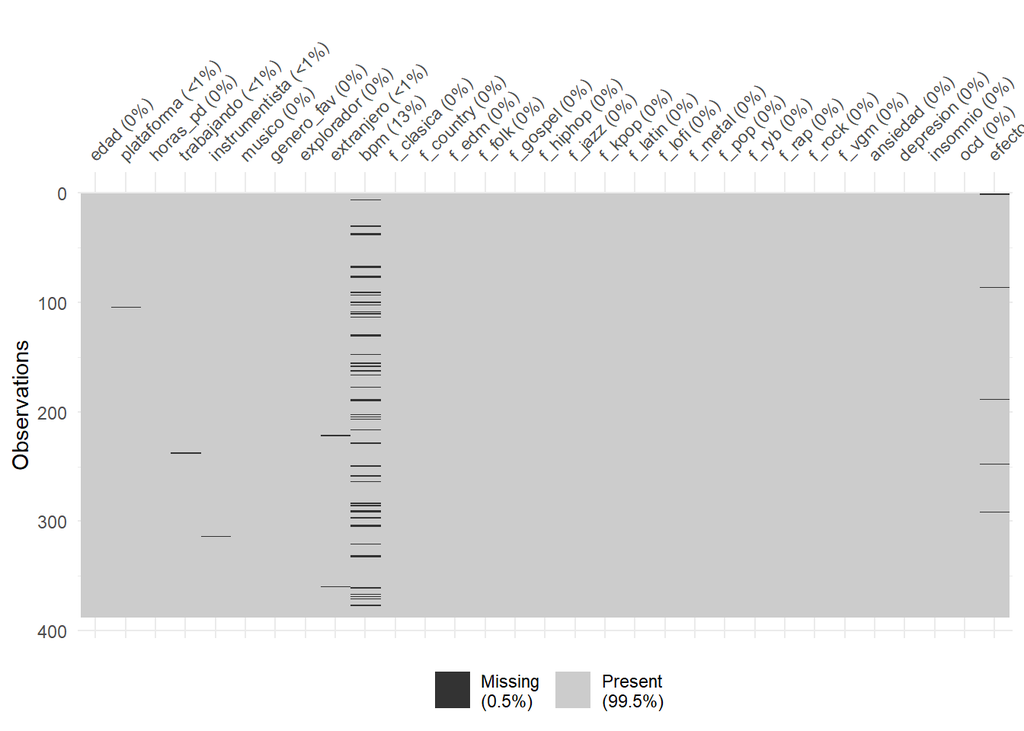

```r
vis_miss(datos_train)
```

**Código**

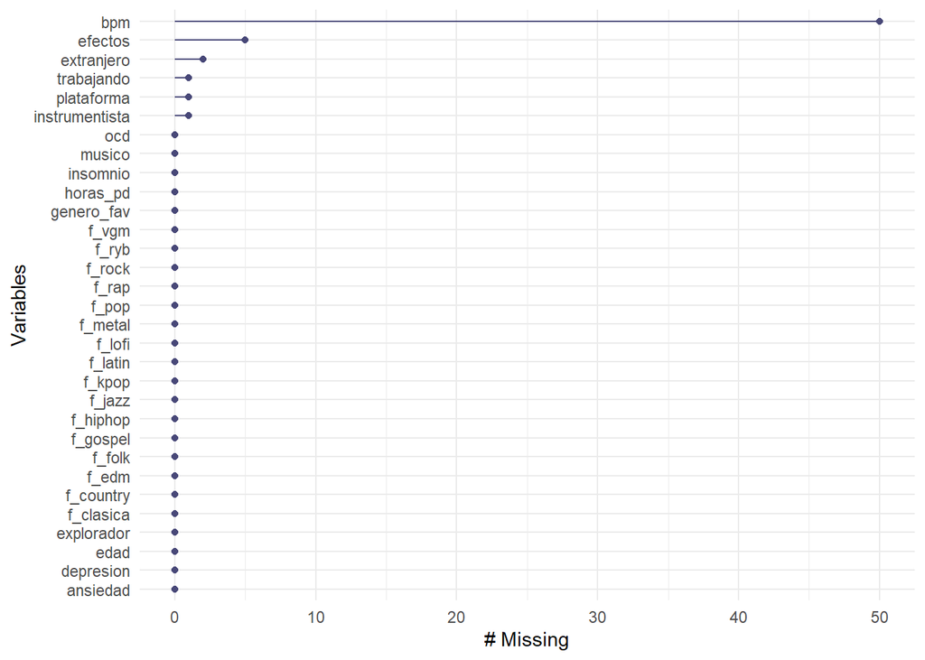

```r
gg_miss_var(datos_train)
```

Como podemos observar el 13% de las respuestas de esa variable son un valor nulo.

**Código**

```r
#Ver resumen estadístico básico (mínimo, máximo, cuartiles)
summary(datos_train$bpm)
```

```
     Min.   1st Qu.    Median      Mean   3rd Qu.      Max.      NA's
        0        99       120   2967481       145 999999999        50
```

**Código**

```r
#Contar valores en cada rango
por_encima_220 <- sum(datos_train$bpm > 220, na.rm = TRUE)
entre_40_y_220 <- sum(datos_train$bpm >= 40 & datos_train$bpm <= 220, na.rm = TRUE)
por_debajo_40  <- sum(datos_train$bpm < 40, na.rm = TRUE)

cat("Mayores a 220 BPM:", por_encima_220, "\n")
```

```
Mayores a 220 BPM: 1
```

**Código**

```r
cat("Entre 40 y 220 BPM:", entre_40_y_220, "\n")
```

```
Entre 40 y 220 BPM: 332
```

**Código**

```r
cat("Menores a 40 BPM:", por_debajo_40, "\n")
```

```
Menores a 40 BPM: 4
```

**Código**

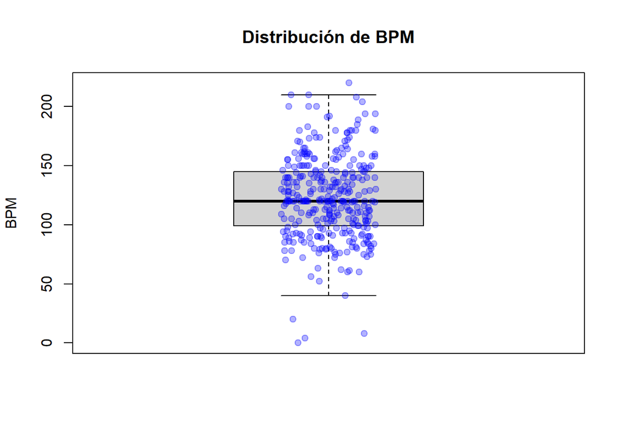

```r
#Veamos la distribución escalando porque tenemos presencia de datos atípicos
boxplot(datos_train$bpm,
        main = "Distribución de BPM",
        ylab = "BPM",
        ylim = c(0, 220),
        outline = FALSE)
stripchart(datos_train$bpm,
           method = "jitter",
           vertical = TRUE,
           add = TRUE,
           pch = 19,
           col = rgb(0, 0, 1, 0.3))
```

Los valores típicos de bpm en la música oscilan habitualmente entre los 40 y los 220 bpm, pero podemos ver que tenemos 4 valores atípicos por debajo de 40 y 1 por encima de 220, además de tener en la partición 50 NA. Claramente la media está siendo afectada por el valor atípico superior, pues está varias escalas por encima.

Vamos a transformar las entradas atípicas en NA por ahora, considerando que se han rellenado con desconocimiento, para poder analizar de forma más sencilla, si debemos mantener o no la variable bpm.

**Código**

```r
#Creamos la copia para guardar el previo al cambio
datos_train_bpm <- datos_train
#Convertimos en NA los valores fuera del rango normal
datos_train$bpm[datos_train$bpm < 40 | datos_train$bpm > 220] <- NA
summary(datos_train$bpm)
```

```
   Min. 1st Qu.  Median    Mean 3rd Qu.    Max.    NA's
     40     100     120     124     145     220      55
```

**Código**

```r
#Vemos que porcentaje de NA queda en esa variable
pct_na <- mean(is.na(datos_train$bpm)) * 100
cat("Porcentaje de NAs:", round(pct_na, 2), "%\n")
```

```
Porcentaje de NAs: 14.21 %
```

**Código**

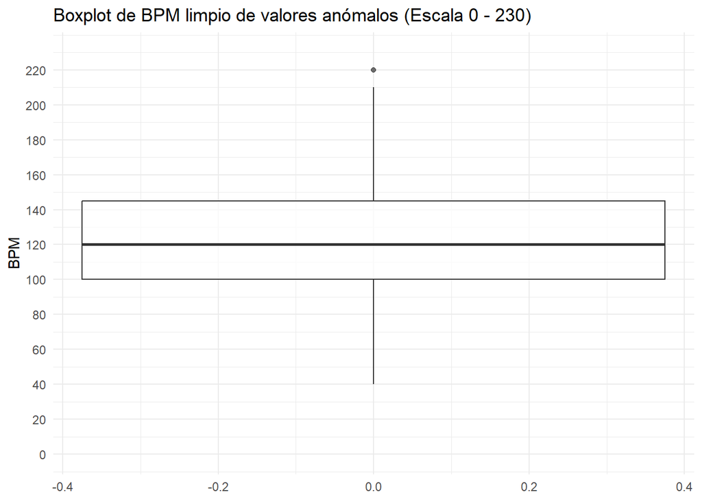

```r
#boxplot post limpieza de anomalias
ggplot(subset(datos_train, !is.na(bpm)), aes(y = bpm)) +
  geom_boxplot( alpha = 0.7) +
  scale_y_continuous(limits = c(0, 230), breaks = seq(0, 230, by = 20)) +
  labs(title = "Boxplot de BPM limpio de valores anómalos (Escala 0 - 230)", y = "BPM") +
  theme_minimal()
```

Vemos que el boxplot se concentra entre 100 y 150, con un valor más límite en 120.

Por otro lado, nos sale un porcentaje que puede ser bastante significativo, vamos a profundizar el análisis. Para ello vamos a ver un boxplot con efectos, hacer un anova y utilizar métodos que nos digan la ganancia de información que aporta la variable.

**Código**

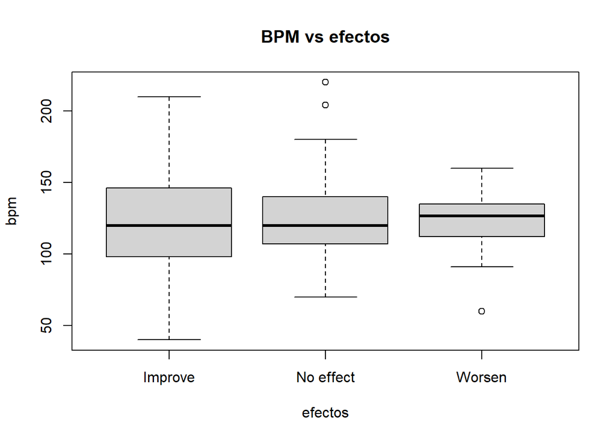

```r
#Comparar la distribución de BPM con la variable respuesta efecto
boxplot(bpm ~ efectos, data = datos_train,
        main = "BPM vs efectos")
```

**Código**

```r
#modelo ANOVA
modelo_anova <- aov(bpm ~ efectos, data = datos_train)
summary(modelo_anova)
```

```
             Df Sum Sq Mean Sq F value Pr(>F)
efectos       2    298   149.2   0.136  0.873
Residuals   326 357166  1095.6
58 observations deleted due to missingness
```

**Código**

```r
information_gain(efectos ~ bpm, data = datos_train)
```

```
  attributes importance
1        bpm          0
```

**Resultado boxplot:** Vemos que tienen medianas similares, entorno a 120 ,en los tres outputs de la variable respuesta, sumado a que parecen tener distribuciones similares, es el primer indicio de que no aporta mucho esta variable.

**Test de ganancia de informacion:** este test nos da 0, por lo que la variable no parece aportar nada de inforación para la variable respuesta.

Por todos estos resultados junto con la gran cantidad de datos faltantes de esta variable, podemos concluir que esta variable parece no aportarnos mucho, por ello la dejaremos en **cuarentena**. Y posteriormente iremos comparando si nos aporta, por si acaso.

**Código**

```r
#"Eliminamos/dejamos en cuarentena bpm"
datos_train_sinbpm <- datos_train %>%
  select(-bpm)
head(datos_train_sinbpm)
```

```
   edad                        plataforma horas_pd trabajando instrumentista
1    18                           Spotify      3.0        Yes            Yes
4    61                     YouTube Music      2.5        Yes             No
5    18                           Spotify      4.0        Yes             No
6    18                           Spotify      5.0        Yes            Yes
10   18 I do not use a streaming service.      1.0        Yes             No
11   18                           Spotify      3.0        Yes            Yes
   musico    genero_fav explorador extranjero f_clasica       f_country  f_edm
1     Yes Otros géneros        Yes        Yes    Rarely           Never Rarely
4     Yes          Jazz        Yes        Yes Sometimes           Never  Never
5      No           R&B        Yes         No     Never           Never Rarely
6     Yes          Jazz        Yes        Yes    Rarely       Sometimes  Never
10     No           R&B        Yes        Yes    Rarely          Rarely Rarely
11     No       Country        Yes         No     Never Very frequently  Never
   f_folk  f_gospel        f_hiphop          f_jazz          f_kpop
```

[output cut: 27 more lines]

A continuación vamos a imputar los datos faltantes del resto de variables, para lo que usaremos arboles de regresión. Intentaremos guardar la forma de imputar los datos para cuando trabajemos con los conjuntos de validación y test.

**Código**

```r
#Receta de imputación
#Excluimos la variable objetivo
predictores <- setdiff(names(datos_train_sinbpm), "efectos")
#Crear receta
receta <- recipe(~ ., data = datos_train_sinbpm[, predictores, drop = FALSE]) |>
  step_impute_bag(extranjero,instrumentista,trabajando,plataforma, # variables a imputar
                  trees = 25,seed_val = 123)

#Aplicamos a train
receta_entrenada <- prep(receta,training = datos_train_sinbpm[, predictores, drop = FALSE])

#Guardamos la "receta"
saveRDS(receta_entrenada,file = "receta_imputacion.rds")

#Cargamos la receta
receta_recuperada <- readRDS("receta_imputacion.rds")

# Función para imputar nuevos datos
imputar_datos <- function(df, receta, predictores) {
  # Imputar exclusivamente las variables predictoras
  x_imputado <- bake(receta,new_data = df[, predictores, drop = FALSE])
  # Sustituir las variables originales
  df[predictores] <- as.data.frame(x_imputado)
  return(df)
}

datos_train_imp <- imputar_datos(datos_train_sinbpm, receta_recuperada, predictores) #aqui le aplicamos la imputación creada
head(datos_train_imp)
```

```
   edad                        plataforma horas_pd trabajando instrumentista
1    18                           Spotify      3.0        Yes            Yes
4    61                     YouTube Music      2.5        Yes             No
5    18                           Spotify      4.0        Yes             No
6    18                           Spotify      5.0        Yes            Yes
10   18 I do not use a streaming service.      1.0        Yes             No
11   18                           Spotify      3.0        Yes            Yes
   musico    genero_fav explorador extranjero f_clasica       f_country  f_edm
1     Yes Otros géneros        Yes        Yes    Rarely           Never Rarely
4     Yes          Jazz        Yes        Yes Sometimes           Never  Never
5      No           R&B        Yes         No     Never           Never Rarely
6     Yes          Jazz        Yes        Yes    Rarely       Sometimes  Never
10     No           R&B        Yes        Yes    Rarely          Rarely Rarely
11     No       Country        Yes         No     Never Very frequently  Never
   f_folk  f_gospel        f_hiphop          f_jazz          f_kpop
```

[output cut: 27 more lines]

**Código**

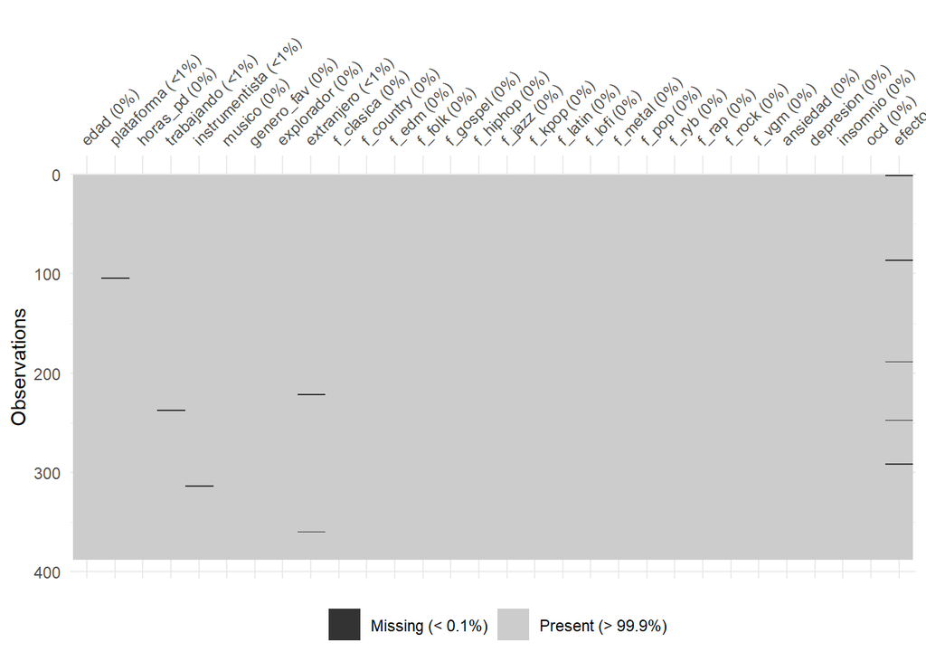

```r
vis_miss(datos_train_sinbpm)
```

**Código**

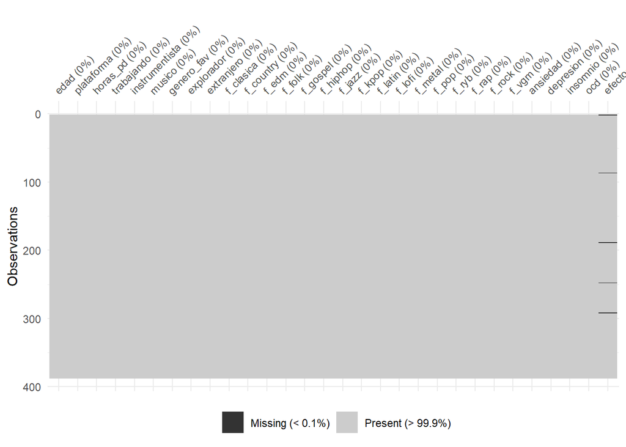

```r
vis_miss(datos_train_imp)
```

Ahora veamos un resumen global de los datos imputados.

**Código**

```r
summary(datos_train_imp)
```

```
      edad                                   plataforma     horas_pd
 Min.   :10.00   Apple Music                      : 24   Min.   : 0.000
 1st Qu.:18.00   I do not use a streaming service.: 37   1st Qu.: 2.000
 Median :20.00   Other streaming service          : 23   Median : 3.000
 Mean   :23.84   Pandora                          :  5   Mean   : 3.679
 3rd Qu.:26.00   Spotify                          :256   3rd Qu.: 5.000
 Max.   :73.00   YouTube Music                    : 42   Max.   :24.000

 trabajando instrumentista musico               genero_fav  explorador
 No : 74    No :263        No :321   Rock            : 84   No :109
 Yes:313    Yes:124        Yes: 66   Pop             : 64   Yes:278
                                     Metal           : 52
                                     Classical       : 27
                                     Video game music: 25
                                     EDM             : 21
                                     (Other)         :114
 extranjero           f_clasica             f_country               f_edm
 No :174    Never          : 82   Never          :186   Never          :164
 Yes:213    Rarely         :136   Rarely         :123   Rarely         :103
            Sometimes      :111   Sometimes      : 49   Sometimes      : 73
            Very frequently: 58   Very frequently: 29   Very frequently: 47



             f_folk               f_gospel              f_hiphop
 Never          :155   Never          :287   Never          : 89
 Rarely         :119   Rarely         : 71   Rarely         :115
 Sometimes      : 73   Sometimes      : 22   Sometimes      :116
 Very frequently: 40   Very frequently:  7   Very frequently: 67



             f_jazz                f_kpop               f_latin
 Never          :136   Never          :220   Never          :236
 Rarely         :130   Rarely         : 89   Rarely         : 87
 Sometimes      : 93   Sometimes      : 35   Sometimes      : 45
 Very frequently: 28   Very frequently: 43   Very frequently: 19



```

[output cut: 16 more lines]

```
             f_vgm        ansiedad        depresion         insomnio
 Never          :118   Min.   : 0.000   Min.   : 0.000   Min.   : 0.000
 Rarely         :101   1st Qu.: 4.000   1st Qu.: 2.000   1st Qu.: 1.000
 Sometimes      :104   Median : 6.000   Median : 5.000   Median : 3.000
 Very frequently: 64   Mean   : 5.844   Mean   : 4.836   Mean   : 3.496
                       3rd Qu.: 8.000   3rd Qu.: 7.000   3rd Qu.: 6.000
                       Max.   :10.000   Max.   :10.000   Max.   :10.000

      ocd              efectos
 Min.   : 0.000   Improve  :283
 1st Qu.: 0.000   No effect: 89
 Median : 2.000   Worsen   : 10
 Mean   : 2.745   NA's     :  5
 3rd Qu.: 5.000
 Max.   :10.000
```

**Código**

```r
print(dfSummary(datos_train_imp),method = "render")
```

Data Frame Summary

datos_train_imp

**Dimensions**: 387 x 30  
**Duplicates**: 0

| **No** | **Variable** | **Stats / Values** | **Freqs (% of Valid)** | **Graph** | **Valid** | **Missing** |
| --- | --- | --- | --- | --- | --- | --- |
| 1 | edad [integer] | Mean (sd) : 23.8 (10.6) min ≤ med ≤ max: 10 ≤ 20 ≤ 73 IQR (CV) : 8 (0.4) | 50 distinct values |  | 387 (100.0%) | 0 (0.0%) |
| 2 | plataforma [factor] | 1. Apple Music 2. I do not use a streaming 3. Other streaming service 4. Pandora 5. Spotify 6. YouTube Music | 24 ( 6.2% ) 37 ( 9.6% ) 23 ( 5.9% ) 5 ( 1.3% ) 256 ( 66.1% ) 42 ( 10.9% ) |  | 387 (100.0%) | 0 (0.0%) |
| 3 | horas_pd [numeric] | Mean (sd) : 3.7 (3.1) min ≤ med ≤ max: 0 ≤ 3 ≤ 24 IQR (CV) : 3 (0.8) | 22 distinct values |  | 387 (100.0%) | 0 (0.0%) |
| 4 | trabajando [factor] | 1. No 2. Yes | 74 ( 19.1% ) 313 ( 80.9% ) |  | 387 (100.0%) | 0 (0.0%) |
| 5 | instrumentista [factor] | 1. No 2. Yes | 263 ( 68.0% ) 124 ( 32.0% ) |  | 387 (100.0%) | 0 (0.0%) |
| 6 | musico [factor] | 1. No 2. Yes | 321 ( 82.9% ) 66 ( 17.1% ) |  | 387 (100.0%) | 0 (0.0%) |
| 7 | genero_fav [factor] | 1. Classical 2. Country 3. EDM 4. Folk 5. Otros géneros 6. Hip hop 7. Jazz 8. K pop 9. Metal 10. Pop [ 4 others ] | 27 ( 7.0% ) 16 ( 4.1% ) 21 ( 5.4% ) 9 ( 2.3% ) 9 ( 2.3% ) 18 ( 4.7% ) 12 ( 3.1% ) 16 ( 4.1% ) 52 ( 13.4% ) 64 ( 16.5% ) 143 ( 37.0% ) |  | 387 (100.0%) | 0 (0.0%) |
| 8 | explorador [factor] | 1. No 2. Yes | 109 ( 28.2% ) 278 ( 71.8% ) |  | 387 (100.0%) | 0 (0.0%) |
| 9 | extranjero [factor] | 1. No 2. Yes | 174 ( 45.0% ) 213 ( 55.0% ) |  | 387 (100.0%) | 0 (0.0%) |
| 10 | f_clasica [ordered, factor] | 1. Never 2. Rarely 3. Sometimes 4. Very frequently | 82 ( 21.2% ) 136 ( 35.1% ) 111 ( 28.7% ) 58 ( 15.0% ) |  | 387 (100.0%) | 0 (0.0%) |
| 11 | f_country [ordered, factor] | 1. Never 2. Rarely 3. Sometimes 4. Very frequently | 186 ( 48.1% ) 123 ( 31.8% ) 49 ( 12.7% ) 29 ( 7.5% ) |  | 387 (100.0%) | 0 (0.0%) |
| 12 | f_edm [ordered, factor] | 1. Never 2. Rarely 3. Sometimes 4. Very frequently | 164 ( 42.4% ) 103 ( 26.6% ) 73 ( 18.9% ) 47 ( 12.1% ) |  | 387 (100.0%) | 0 (0.0%) |
| 13 | f_folk [ordered, factor] | 1. Never 2. Rarely 3. Sometimes 4. Very frequently | 155 ( 40.1% ) 119 ( 30.7% ) 73 ( 18.9% ) 40 ( 10.3% ) |  | 387 (100.0%) | 0 (0.0%) |
| 14 | f_gospel [ordered, factor] | 1. Never 2. Rarely 3. Sometimes 4. Very frequently | 287 ( 74.2% ) 71 ( 18.3% ) 22 ( 5.7% ) 7 ( 1.8% ) |  | 387 (100.0%) | 0 (0.0%) |
| 15 | f_hiphop [ordered, factor] | 1. Never 2. Rarely 3. Sometimes 4. Very frequently | 89 ( 23.0% ) 115 ( 29.7% ) 116 ( 30.0% ) 67 ( 17.3% ) |  | 387 (100.0%) | 0 (0.0%) |
| 16 | f_jazz [ordered, factor] | 1. Never 2. Rarely 3. Sometimes 4. Very frequently | 136 ( 35.1% ) 130 ( 33.6% ) 93 ( 24.0% ) 28 ( 7.2% ) |  | 387 (100.0%) | 0 (0.0%) |
| 17 | f_kpop [ordered, factor] | 1. Never 2. Rarely 3. Sometimes 4. Very frequently | 220 ( 56.8% ) 89 ( 23.0% ) 35 ( 9.0% ) 43 ( 11.1% ) |  | 387 (100.0%) | 0 (0.0%) |
| 18 | f_latin [ordered, factor] | 1. Never 2. Rarely 3. Sometimes 4. Very frequently | 236 ( 61.0% ) 87 ( 22.5% ) 45 ( 11.6% ) 19 ( 4.9% ) |  | 387 (100.0%) | 0 (0.0%) |
| 19 | f_lofi [ordered, factor] | 1. Never 2. Rarely 3. Sometimes 4. Very frequently | 153 ( 39.5% ) 99 ( 25.6% ) 94 ( 24.3% ) 41 ( 10.6% ) |  | 387 (100.0%) | 0 (0.0%) |
| 20 | f_metal [ordered, factor] | 1. Never 2. Rarely 3. Sometimes 4. Very frequently | 146 ( 37.7% ) 91 ( 23.5% ) 64 ( 16.5% ) 86 ( 22.2% ) |  | 387 (100.0%) | 0 (0.0%) |
| 21 | f_pop [ordered, factor] | 1. Never 2. Rarely 3. Sometimes 4. Very frequently | 32 ( 8.3% ) 71 ( 18.3% ) 126 ( 32.6% ) 158 ( 40.8% ) |  | 387 (100.0%) | 0 (0.0%) |
| 22 | f_ryb [ordered, factor] | 1. Never 2. Rarely 3. Sometimes 4. Very frequently | 109 ( 28.2% ) 120 ( 31.0% ) 84 ( 21.7% ) 74 ( 19.1% ) |  | 387 (100.0%) | 0 (0.0%) |
| 23 | f_rap [ordered, factor] | 1. Never 2. Rarely 3. Sometimes 4. Very frequently | 94 ( 24.3% ) 123 ( 31.8% ) 93 ( 24.0% ) 77 ( 19.9% ) |  | 387 (100.0%) | 0 (0.0%) |
| 24 | f_rock [ordered, factor] | 1. Never 2. Rarely 3. Sometimes 4. Very frequently | 57 ( 14.7% ) 48 ( 12.4% ) 116 ( 30.0% ) 166 ( 42.9% ) |  | 387 (100.0%) | 0 (0.0%) |
| 25 | f_vgm [ordered, factor] | 1. Never 2. Rarely 3. Sometimes 4. Very frequently | 118 ( 30.5% ) 101 ( 26.1% ) 104 ( 26.9% ) 64 ( 16.5% ) |  | 387 (100.0%) | 0 (0.0%) |
| 26 | ansiedad [numeric] | Mean (sd) : 5.8 (2.8) min ≤ med ≤ max: 0 ≤ 6 ≤ 10 IQR (CV) : 4 (0.5) | 12 distinct values |  | 387 (100.0%) | 0 (0.0%) |
| 27 | depresion [numeric] | Mean (sd) : 4.8 (3) min ≤ med ≤ max: 0 ≤ 5 ≤ 10 IQR (CV) : 5 (0.6) | 12 distinct values |  | 387 (100.0%) | 0 (0.0%) |
| 28 | insomnio [numeric] | Mean (sd) : 3.5 (3) min ≤ med ≤ max: 0 ≤ 3 ≤ 10 IQR (CV) : 5 (0.9) | 11 distinct values |  | 387 (100.0%) | 0 (0.0%) |
| 29 | ocd [numeric] | Mean (sd) : 2.7 (2.9) min ≤ med ≤ max: 0 ≤ 2 ≤ 10 IQR (CV) : 5 (1) | 12 distinct values |  | 387 (100.0%) | 0 (0.0%) |
| 30 | efectos [factor] | 1. Improve 2. No effect 3. Worsen | 283 ( 74.1% ) 89 ( 23.3% ) 10 ( 2.6% ) |  | 382 (98.7%) | 5 (1.3%) |

Generated by summarytools 1.1.4 ([R](https://www.r-project.org/) version 4.5.2)  
2026-11-03

También nos falta eliminar los NA de la variable respuesta que no han sido imputados.

**Código**

```r
datos_train_imp <- datos_train_imp[!is.na(datos_train_imp[[ncol(datos_train_imp)]]), ]
```

**Ahora miremos algunos gráficos para seguir explorando los datos.**

Veamos la matriz de correlaciones de las variables numéricas

**Código**

```r
#Matriz de correlaciones
#Seleccionamos las variables numéricas
vars_numericas <- datos_train_imp[, sapply(datos_train_imp, is.numeric)]

#Cálculo de la matriz de correlación
matriz_cor <- round(cor(vars_numericas, use = "complete.obs"), 2)
print(matriz_cor)
```

```
           edad horas_pd ansiedad depresion insomnio   ocd
edad       1.00    -0.07    -0.13     -0.05     0.06 -0.10
horas_pd  -0.07     1.00     0.16      0.16     0.18  0.21
ansiedad  -0.13     0.16     1.00      0.51     0.29  0.34
depresion -0.05     0.16     0.51      1.00     0.40  0.20
insomnio   0.06     0.18     0.29      0.40     1.00  0.26
ocd       -0.10     0.21     0.34      0.20     0.26  1.00
```

**Código**

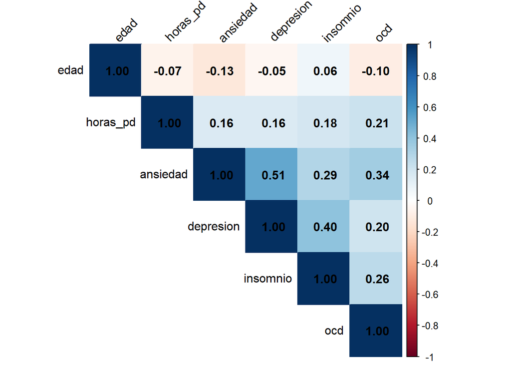

```r
corrplot(matriz_cor, method = "color", type = "upper",
         tl.col = "black", tl.srt = 45, addCoef.col = "black")
```

La correlación que más llama la atención es la de ansiedad y depresión que es la más alta entre todas aunque no deja de ser solo de 0,51.

Como hemos visto que la correlación que más llama la atención es entre ansiedad y depresión, vamos a realizar un modelo de regresión lineal entre ellas.

**Código**

```r
modelo_depresion_ansiedad <- lm(depresion ~ ansiedad, data = datos_train_imp)
summary(modelo_depresion_ansiedad)
```

```
Call:
lm(formula = depresion ~ ansiedad, data = datos_train_imp)

Residuals:
    Min      1Q  Median      3Q     Max
-6.5389 -1.6753 -0.0793  1.6227  6.7035

Coefficients:
            Estimate Std. Error t value Pr(>|t|)
(Intercept)  1.67531    0.30576   5.479  7.8e-08 ***
ansiedad     0.54040    0.04721  11.447  < 2e-16 ***
---
Signif. codes:  0 '***' 0.001 '**' 0.01 '*' 0.05 '.' 0.1 ' ' 1

Residual standard error: 2.565 on 380 degrees of freedom
Multiple R-squared:  0.2564,    Adjusted R-squared:  0.2544
F-statistic:   131 on 1 and 380 DF,  p-value: < 2.2e-16
```

**Código**

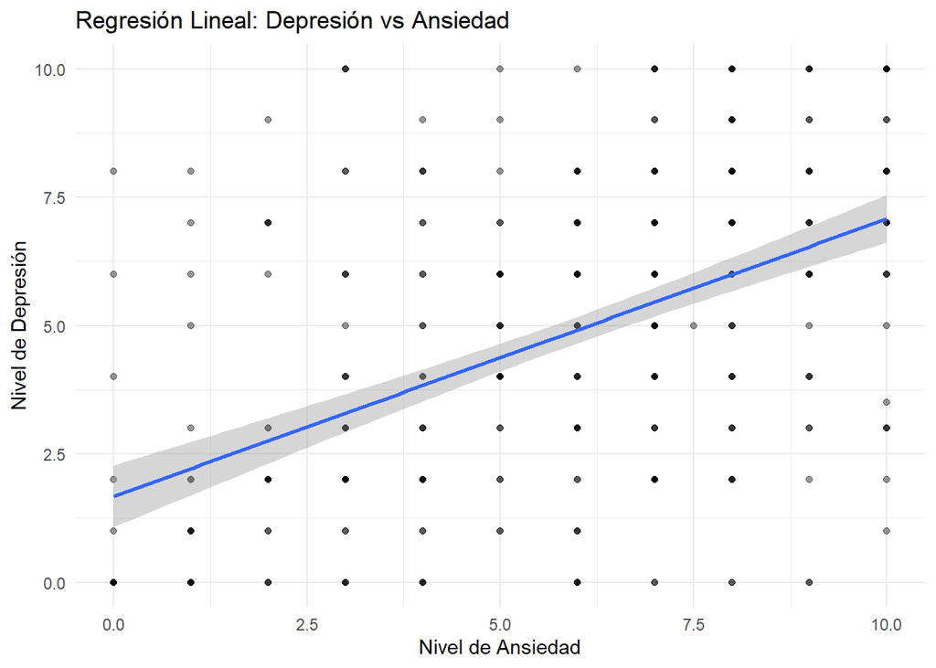

```r
ggplot(datos_train_imp, aes(x = ansiedad, y = depresion)) +
  geom_point(alpha = 0.4) +
  geom_smooth(method = "lm", se = TRUE) +
  labs(
    title = "Regresión Lineal: Depresión vs Ansiedad",
    x = "Nivel de Ansiedad",
    y = "Nivel de Depresión"
  ) +
  theme_minimal()
```

Según el modelo, por cada punto de ansiedad, aumenta la depresión 0,54 puntos. Además el p-valor es muy inferior a 0,05, por lo que hay una relación estadísticamente significativa entre estas dos variables. Además, el estadístico F es suficientemente grande, por lo que el modelo calcula una cantidad relevante de información, pues es el ratio entre la variabilidad explicada y la no explicada. Con solo la ansiedad (según es R^2 ajustado) podemos explicar un 25% de la variabilidad de la depresión.

**Código**

```r
modelo_depresion_ansiedad_insomnio <- lm(depresion ~ ansiedad+insomnio, data = datos_train_imp)
summary(modelo_depresion_ansiedad_insomnio)
```

```
Call:
lm(formula = depresion ~ ansiedad + insomnio, data = datos_train_imp)

Residuals:
    Min      1Q  Median      3Q     Max
-6.6739 -1.6733 -0.1321  1.5266  7.4022

Coefficients:
            Estimate Std. Error t value Pr(>|t|)
(Intercept)  1.23076    0.30034   4.098 5.10e-05 ***
ansiedad     0.45570    0.04706   9.684  < 2e-16 ***
insomnio     0.26839    0.04321   6.211 1.39e-09 ***
---
Signif. codes:  0 '***' 0.001 '**' 0.01 '*' 0.05 '.' 0.1 ' ' 1

Residual standard error: 2.447 on 379 degrees of freedom
Multiple R-squared:  0.3251,    Adjusted R-squared:  0.3215
F-statistic: 91.28 on 2 and 379 DF,  p-value: < 2.2e-16
```

Por curiosidad, al ser la correlación entre depresión e insomnio de 0,4, hemos, hecho un modelo multilineal, el cual sigue saliendo significativo, aumentando la variabilidad explicada hasta un 32% (Ansiedad e insomnio respecto depresión).

**Código**

```r
anova(modelo_depresion_ansiedad, modelo_depresion_ansiedad_insomnio)
```

```
Analysis of Variance Table

Model 1: depresion ~ ansiedad
Model 2: depresion ~ ansiedad + insomnio
  Res.Df    RSS Df Sum of Sq      F    Pr(>F)
1    380 2500.8
2    379 2269.7  1    231.03 38.577 1.385e-09 ***
---
Signif. codes:  0 '***' 0.001 '**' 0.01 '*' 0.05 '.' 0.1 ' ' 1
```

Al comparar los dos modelos, vemos que el error se reduce bastante el error, además el p-valor que nos da el ANOVA es suficientemente pequeño como para rechazar la hipotesis nula de que añadir insomnio no mejora la explicabilidad de la variable depresión.

Viendo estos modelos, parece ser que por lo menos estas 3 variables van a ir de la mano. Probemos a terminar de añadir la otra enfermedad (ocd).

**Código**

```r
modelo_dep_todo <- lm(depresion ~ ansiedad+insomnio+ocd, data = datos_train_imp)
summary(modelo_dep_todo)
```

```
Call:
lm(formula = depresion ~ ansiedad + insomnio + ocd, data = datos_train_imp)

Residuals:
    Min      1Q  Median      3Q     Max
-6.5678 -1.6674 -0.1269  1.5611  7.3791

Coefficients:
            Estimate Std. Error t value Pr(>|t|)
(Intercept)  1.23789    0.30129   4.109 4.88e-05 ***
ansiedad     0.46100    0.04921   9.367  < 2e-16 ***
insomnio     0.27132    0.04397   6.170 1.75e-09 ***
ocd         -0.01757    0.04714  -0.373     0.71
---
Signif. codes:  0 '***' 0.001 '**' 0.01 '*' 0.05 '.' 0.1 ' ' 1

Residual standard error: 2.45 on 378 degrees of freedom
Multiple R-squared:  0.3253,    Adjusted R-squared:   0.32
F-statistic: 60.76 on 3 and 378 DF,  p-value: < 2.2e-16
```

En este caso el añadir la variable ha reducido el R^2 ajustado, frente al modelo anterior, por lo que añadir esta variable no compensa (el R^2 ajustado penaliza , ya que sino de por si, el R^2 crecería siempre con cada variable).

Seguimos nuestro análisis con un diagrama de cajas para ver la relación de efectos con la cantidad de horas de escucha de música.

**Código**

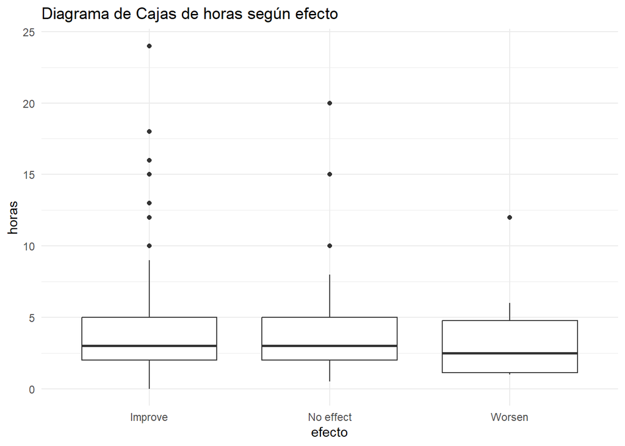

```r
#Diagrama de cajas
ggplot(datos_train_imp, aes(x = efectos, y = horas_pd)) +
  geom_boxplot() +
  labs(title = "Diagrama de Cajas de horas según efecto",
       x = "efecto",
       y = "horas") +
  theme_minimal() +
  theme(legend.position = "none")
```

Vemos que entre improve y no effect tenemos un boxplot bastante similar con medianas similares. Por otro lado los que empeoran parecen escuchar algo menos de música, aunque habría que profundizar, antes de sacar conclusiones, pues la diferencia es bastante pequeña.

Ahora, ya que hemos entrado en el análisis de algunos datos relacionados con los hábitos, probemos a realizar modelos multilineales entre las enfermedades y los hábitos musicales de las personas (horas_pd, músico, extranjero, explorador, etc).

**Código**

```r
modelo_multilineal_depresion <- lm(depresion ~ horas_pd+ trabajando + instrumentista + musico+explorador+extranjero,
  data = datos_train_imp)
summary(modelo_multilineal_depresion)
```

```
Call:
lm(formula = depresion ~ horas_pd + trabajando + instrumentista +
    musico + explorador + extranjero, data = datos_train_imp)

Residuals:
    Min      1Q  Median      3Q     Max
-6.6892 -2.3740  0.3645  2.2461  6.0502

Coefficients:
                  Estimate Std. Error t value Pr(>|t|)
(Intercept)        4.21913    0.42024  10.040  < 2e-16 ***
horas_pd           0.14154    0.05120   2.764  0.00598 **
trabajandoYes     -0.12953    0.40394  -0.321  0.74863
instrumentistaYes  0.01385    0.36175   0.038  0.96949
musicoYes          0.64843    0.45049   1.439  0.15087
exploradorYes     -0.28132    0.34976  -0.804  0.42172
extranjeroYes      0.52199    0.30758   1.697  0.09051 .
---
Signif. codes:  0 '***' 0.001 '**' 0.01 '*' 0.05 '.' 0.1 ' ' 1

Residual standard error: 2.937 on 375 degrees of freedom
Multiple R-squared:  0.03828,   Adjusted R-squared:  0.02289
F-statistic: 2.488 on 6 and 375 DF,  p-value: 0.02261
```

**Código**

```r
modelo_multilineal_ocd <- lm(ocd ~ horas_pd+ trabajando + instrumentista + musico+explorador+extranjero,
  data = datos_train_imp)
summary(modelo_multilineal_ocd)
```

```
Call:
lm(formula = ocd ~ horas_pd + trabajando + instrumentista + musico +
    explorador + extranjero, data = datos_train_imp)

Residuals:
   Min     1Q Median     3Q    Max
-5.094 -2.262 -0.781  1.881  7.982

Coefficients:
                   Estimate Std. Error t value Pr(>|t|)
(Intercept)        2.026201   0.405074   5.002 8.73e-07 ***
horas_pd           0.203881   0.049352   4.131 4.45e-05 ***
trabajandoYes      0.009698   0.389355   0.025    0.980
instrumentistaYes  0.128771   0.348693   0.369    0.712
musicoYes         -0.476928   0.434227  -1.098    0.273
exploradorYes      0.175230   0.337132   0.520    0.604
extranjeroYes     -0.212262   0.296481  -0.716    0.474
---
Signif. codes:  0 '***' 0.001 '**' 0.01 '*' 0.05 '.' 0.1 ' ' 1

Residual standard error: 2.831 on 375 degrees of freedom
Multiple R-squared:  0.0496,    Adjusted R-squared:  0.03439
F-statistic: 3.262 on 6 and 375 DF,  p-value: 0.003873
```

**Código**

```r
modelo_multilineal_insomnio <- lm(insomnio ~ horas_pd+ trabajando + instrumentista + musico+explorador+extranjero,
  data = datos_train_imp)
summary(modelo_multilineal_insomnio)
```

```
Call:
lm(formula = insomnio ~ horas_pd + trabajando + instrumentista +
    musico + explorador + extranjero, data = datos_train_imp)

Residuals:
    Min      1Q  Median      3Q     Max
-6.7609 -2.7453 -0.4273  2.6802  7.0846

Coefficients:
                  Estimate Std. Error t value Pr(>|t|)
(Intercept)        2.91539    0.42844   6.805 4.02e-11 ***
horas_pd           0.16601    0.05220   3.180  0.00159 **
trabajandoYes     -0.09591    0.41181  -0.233  0.81597
instrumentistaYes -0.13324    0.36880  -0.361  0.71810
musicoYes          0.77087    0.45927   1.678  0.09409 .
exploradorYes     -0.04279    0.35658  -0.120  0.90454
extranjeroYes     -0.01341    0.31358  -0.043  0.96590
---
Signif. codes:  0 '***' 0.001 '**' 0.01 '*' 0.05 '.' 0.1 ' ' 1

Residual standard error: 2.994 on 375 degrees of freedom
Multiple R-squared:  0.03994,   Adjusted R-squared:  0.02458
F-statistic:   2.6 on 6 and 375 DF,  p-value: 0.0176
```

**Código**

```r
modelo_multilineal_ansiedad <- lm(ansiedad ~ horas_pd+ trabajando + instrumentista + musico+explorador+extranjero,
  data = datos_train_imp)
summary(modelo_multilineal_ansiedad)
```

```
Call:
lm(formula = ansiedad ~ horas_pd + trabajando + instrumentista +
    musico + explorador + extranjero, data = datos_train_imp)

Residuals:
   Min     1Q Median     3Q    Max
-7.235 -2.116  0.489  1.954  5.118

Coefficients:
                  Estimate Std. Error t value Pr(>|t|)
(Intercept)        5.27195    0.39291  13.418   <2e-16 ***
horas_pd           0.14758    0.04787   3.083   0.0022 **
trabajandoYes     -0.36582    0.37766  -0.969   0.3334
instrumentistaYes  0.22336    0.33822   0.660   0.5094
musicoYes         -0.09012    0.42119  -0.214   0.8307
exploradorYes     -0.17133    0.32701  -0.524   0.6006
extranjeroYes      0.72003    0.28758   2.504   0.0127 *
---
Signif. codes:  0 '***' 0.001 '**' 0.01 '*' 0.05 '.' 0.1 ' ' 1

Residual standard error: 2.746 on 375 degrees of freedom
Multiple R-squared:  0.04245,   Adjusted R-squared:  0.02712
F-statistic:  2.77 on 6 and 375 DF,  p-value: 0.01199
```

Así pues, parece ser que los hábitos musicales a excepción por ahora de las horas por día, no tienen mucha relación con la autopercepción de las enfermedades mentales.

Probemos ahora solo con las horas por día y los transtornos.

**Código**

```r
modelo_horas_depresion <- lm(depresion ~ horas_pd, data = datos_train_imp)
summary(modelo_horas_depresion)
```

```
Call:
lm(formula = depresion ~ horas_pd, data = datos_train_imp)

Residuals:
    Min      1Q  Median      3Q     Max
-6.5168 -2.5837  0.4163  2.4061  5.7137

Coefficients:
            Estimate Std. Error t value Pr(>|t|)
(Intercept)  4.28627    0.23430  18.294  < 2e-16 ***
horas_pd     0.14870    0.04857   3.062  0.00236 **
---
Signif. codes:  0 '***' 0.001 '**' 0.01 '*' 0.05 '.' 0.1 ' ' 1

Residual standard error: 2.939 on 380 degrees of freedom
Multiple R-squared:  0.02407,   Adjusted R-squared:  0.0215
F-statistic: 9.373 on 1 and 380 DF,  p-value: 0.002359
```

**Código**

```r
modelo_horas_insomnio <- lm(insomnio ~ horas_pd, data = datos_train_imp)
summary(modelo_horas_insomnio)
```

```
Call:
lm(formula = insomnio ~ horas_pd, data = datos_train_imp)

Residuals:
    Min      1Q  Median      3Q     Max
-7.0497 -2.7299 -0.3804  2.6196  7.1438

Coefficients:
            Estimate Std. Error t value Pr(>|t|)
(Intercept)  2.85622    0.23811   11.99  < 2e-16 ***
horas_pd     0.17473    0.04936    3.54  0.00045 ***
---
Signif. codes:  0 '***' 0.001 '**' 0.01 '*' 0.05 '.' 0.1 ' ' 1

Residual standard error: 2.987 on 380 degrees of freedom
Multiple R-squared:  0.03192,   Adjusted R-squared:  0.02937
F-statistic: 12.53 on 1 and 380 DF,  p-value: 0.0004501
```

**Código**

```r
modelo_horas_ansiedad <- lm(ansiedad ~ horas_pd, data = datos_train_imp)
summary(modelo_horas_ansiedad)
```

```
Call:
lm(formula = ansiedad ~ horas_pd, data = datos_train_imp)

Residuals:
   Min     1Q Median     3Q    Max
-6.730 -2.171  0.388  2.108  4.667

Coefficients:
            Estimate Std. Error t value Pr(>|t|)
(Intercept)  5.33260    0.21952   24.29  < 2e-16 ***
horas_pd     0.13972    0.04551    3.07  0.00229 **
---
Signif. codes:  0 '***' 0.001 '**' 0.01 '*' 0.05 '.' 0.1 ' ' 1

Residual standard error: 2.754 on 380 degrees of freedom
Multiple R-squared:  0.0242,    Adjusted R-squared:  0.02164
F-statistic: 9.426 on 1 and 380 DF,  p-value: 0.002293
```

**Código**

```r
modelo_horas_ocd <- lm(ocd ~ horas_pd, data = datos_train_imp)
summary(modelo_horas_ocd)
```

```
Call:
lm(formula = ocd ~ horas_pd, data = datos_train_imp)

Residuals:
    Min      1Q  Median      3Q     Max
-4.9848 -2.2259 -0.8171  1.8480  7.7741

Coefficients:
            Estimate Std. Error t value Pr(>|t|)
(Intercept)  2.02880    0.22474   9.027  < 2e-16 ***
horas_pd     0.19707    0.04659   4.230 2.93e-05 ***
---
Signif. codes:  0 '***' 0.001 '**' 0.01 '*' 0.05 '.' 0.1 ' ' 1

Residual standard error: 2.819 on 380 degrees of freedom
Multiple R-squared:  0.04497,   Adjusted R-squared:  0.04246
F-statistic: 17.89 on 1 and 380 DF,  p-value: 2.932e-05
```

Vemos así que la variable por si sola si que ha mejorado los estadisticos F y que ahora siempre su p-valor está por debajo de 0,05. Aunque, el R^2 no consigue superar el 0,05 (por tanto para ningún transtorno esta variable por si sola explica tan si quiera el 5% de la variabilidad total).

Habiendo tratado algunos temas generales, centremonos ahora en estudiar algunas de las preguntas hechas al comienzo del trabajo.

- **¿Qué género de música es el más habitual entre los géneros favoritos? ¿Y el que menos?**

**Código**

```r
conteo_generos <- datos_train_imp %>%
  mutate(genero_fav = as.character(genero_fav)) %>%
  count(genero_fav, sort = TRUE)
print(conteo_generos)
```

```
         genero_fav  n
1              Rock 83
2               Pop 64
3             Metal 52
4         Classical 27
5  Video game music 25
6               EDM 20
7               R&B 20
8           Hip hop 18
9           Country 16
10            K pop 15
11              Rap 14
12             Jazz 12
13             Folk  8
14    Otros géneros  8
```

**Código**

```r
# Obtener los nombres correctos
genero_mas_habitual  <- conteo_generos %>% slice(1)
genero_menos_habitual <- conteo_generos %>% slice(n())

cat("El género más habitual es:", genero_mas_habitual$genero_fav, "con", genero_mas_habitual$n, "personas.\n")
```

```
El género más habitual es: Rock con 83 personas.
```

**Código**

```r
cat("El género menos habitual es:", genero_menos_habitual$genero_fav, "con", genero_menos_habitual$n, "personas.\n")
```

```
El género menos habitual es: Otros géneros con 8 personas.
```

Podemos apreciar que el rock es el género que más se repite como el favorito de la gente y el menos habitual sin embargo son géneros minoritarios representados por la categoría otros géneros.

Para visualizar mejor los datos de género favorito vamos a realizar un gráfico de barras horizontal.

**Código**

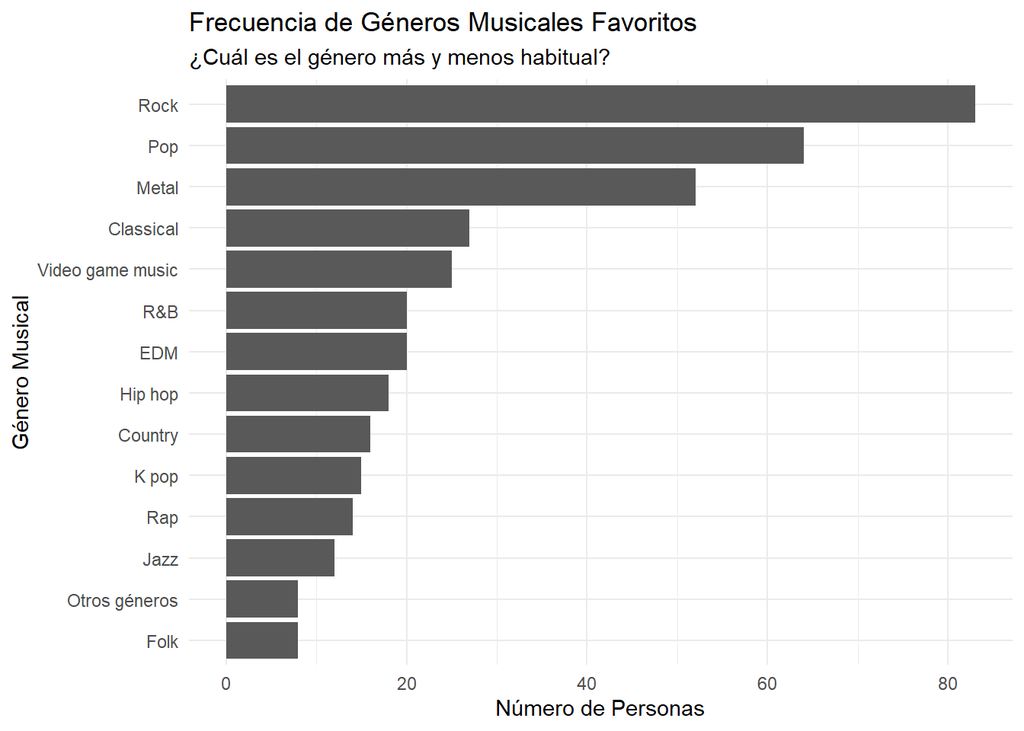

```r
ggplot(datos_train_imp %>% filter(!is.na(genero_fav)), aes(x = reorder(genero_fav, genero_fav, function(x) length(x)))) +
  geom_bar(show.legend = FALSE) +
  coord_flip() + # Pone las barras en horizontal para leer mejor los nombres
  labs(
    title = "Frecuencia de Géneros Musicales Favoritos",
    subtitle = "¿Cuál es el género más y menos habitual?",
    x = "Género Musical",
    y = "Número de Personas"
  ) +
  theme_minimal()
```

Gracias al gráfico vemos que el folk también está empatado con otros géneros, como género menos elegido como favorito.

A partir del análisis de los datos de la encuesta, al observar la variable de género musical favorito, se aprecia claramente que el género preferido entre los participantes es el Rock, seguido por el Pop y que los géneros con menor representación como favoritos son el folk y el conjunto de otros géneros.

Para ello primero agruparemos por edad de 10 en diez a los participante

**Código**

```r
datosAgrupEdad<-datos_train_imp %>% mutate(GrupoEdad=
                                    cut(edad,breaks=seq(10,90,by=10), right=FALSE))
table(datosAgrupEdad$GrupoEdad)
```

```
[10,20) [20,30) [30,40) [40,50) [50,60) [60,70) [70,80) [80,90)
    177     137      39      12       7       9       1       0
```

**Código**

```r
prop.table(table(datosAgrupEdad$GrupoEdad))
```

```
    [10,20)     [20,30)     [30,40)     [40,50)     [50,60)     [60,70)
0.463350785 0.358638743 0.102094241 0.031413613 0.018324607 0.023560209
    [70,80)     [80,90)
0.002617801 0.000000000
```

Como vemos la mayoría están en los primeros tres bloques de 10 años, mientras que a partir de 40 años no tenemos apenas encuestados en nuestra muestra. Por lo que decidiremos agrupar los bloques de las personas con edad de cuarenta en adelante para que así sea más significativo en nuestro estudio.

**Código**

```r
datosEdad<-datos_train_imp %>% mutate(GrupoEdad=case_when(

  edad>=10 & edad<20 ~ "[10,20)",
  edad>=20 & edad<30 ~ "[20,30)",
  edad>=30 & edad<40 ~ "[30,40)",
  edad>=40  ~ "40 o más",
  TRUE~NA_character_
  ))

table(datosEdad$GrupoEdad)
```

```
 [10,20)  [20,30)  [30,40) 40 o más
     177      137       39       29
```

**Código**

```r
prop.table(table(datosEdad$GrupoEdad))
```

```
   [10,20)    [20,30)    [30,40)   40 o más
0.46335079 0.35863874 0.10209424 0.07591623
```

**Código**

```r
cat("\n")
```

**Código**

```r
cat("---Ansiedad---\n")
```

```
---Ansiedad---
```

**Código**

```r
modelo_aov1 <- aov(ansiedad ~ GrupoEdad, data = datosEdad)
summary(modelo_aov1)
```

```
             Df Sum Sq Mean Sq F value Pr(>F)
GrupoEdad     3   68.6   22.88   2.999 0.0306 *
Residuals   378 2884.0    7.63
---
Signif. codes:  0 '***' 0.001 '**' 0.01 '*' 0.05 '.' 0.1 ' ' 1
```

**Código**

```r
TukeyHSD(modelo_aov1)
```

```
  Tukey multiple comparisons of means
    95% family-wise confidence level

Fit: aov(formula = ansiedad ~ GrupoEdad, data = datosEdad)

$GrupoEdad
                       diff        lwr         upr     p adj
[20,30)-[10,20)  -0.0216710 -0.8327624  0.78942044 0.9998823
[30,40)-[10,20)   0.1392873 -1.1215524  1.40012689 0.9919140
40 o más-[10,20) -1.5839665 -3.0118734 -0.15605960 0.0229138
[30,40)-[20,30)   0.1609583 -1.1326884  1.45460488 0.9885417
40 o más-[20,30) -1.5622955 -3.0192523 -0.10533870 0.0301199
40 o más-[30,40) -1.7232538 -3.4709867  0.02447915 0.0549225
```

**Código**

```r
table(datosEdad$GrupoEdad,datosEdad$ansiedad)
```

```
            0  1  2  3  4  5  6  7 7.5  8  9 10
  [10,20)   6  7  8 15 13 15 23 36   1 29  9 15
  [20,30)   5  6  8 14 10  8 19 20   0 20 14 13
  [30,40)   0  5  1  3  3  2  4  6   0  6  4  5
  40 o más  4  2  3  5  2  4  1  2   0  1  2  3
```

**Código**

```r
prop.table(table(datosEdad$GrupoEdad,datosEdad$ansiedad),margin=1)*100
```

```
                    0          1          2          3          4          5
  [10,20)   3.3898305  3.9548023  4.5197740  8.4745763  7.3446328  8.4745763
  [20,30)   3.6496350  4.3795620  5.8394161 10.2189781  7.2992701  5.8394161
  [30,40)   0.0000000 12.8205128  2.5641026  7.6923077  7.6923077  5.1282051
  40 o más 13.7931034  6.8965517 10.3448276 17.2413793  6.8965517 13.7931034

                    6          7        7.5          8          9         10
  [10,20)  12.9943503 20.3389831  0.5649718 16.3841808  5.0847458  8.4745763
  [20,30)  13.8686131 14.5985401  0.0000000 14.5985401 10.2189781  9.4890511
  [30,40)  10.2564103 15.3846154  0.0000000 15.3846154 10.2564103 12.8205128
  40 o más  3.4482759  6.8965517  0.0000000  3.4482759  6.8965517 10.3448276
```

**Código**

```r
cat("\n")
```

**Código**

```r
cat("---Depresión---\n")
```

```
---Depresión---
```

**Código**

```r
modelo_aov2 <- aov(depresion ~ GrupoEdad, data = datosEdad)
summary(modelo_aov2)
```

```
             Df Sum Sq Mean Sq F value  Pr(>F)
GrupoEdad     3    100   33.35   3.863 0.00961 **
Residuals   378   3263    8.63
---
Signif. codes:  0 '***' 0.001 '**' 0.01 '*' 0.05 '.' 0.1 ' ' 1
```

**Código**

```r
TukeyHSD(modelo_aov2)
```

```
  Tukey multiple comparisons of means
    95% family-wise confidence level

Fit: aov(formula = depresion ~ GrupoEdad, data = datosEdad)

$GrupoEdad
                       diff          lwr        upr     p adj
[20,30)-[10,20)   0.8699122  0.007167178  1.7326571 0.0472601
[30,40)-[10,20)   0.6625380 -0.678596904  2.0036730 0.5795709
40 o más-[10,20) -0.7928112 -2.311652926  0.7260305 0.5335764
[30,40)-[20,30)  -0.2073741 -1.583405338  1.1686571 0.9800021
40 o más-[20,30) -1.6627234 -3.212465004 -0.1129818 0.0299882
40 o más-[30,40) -1.4553492 -3.314384775  0.4036863 0.1823545
```

**Código**

```r
table(datosEdad$GrupoEdad,datosEdad$depresion)
```

```
            0  1  2  3 3.5  4  5  6  7  8  9 10
  [10,20)  24  8 22 16   1 14 17 26 15 19  8  7
  [20,30)   7  8 15 12   0  9 10 19 24 15  4 14
  [30,40)   4  1  5  3   0  4  1  8  4  2  1  6
  40 o más  5  1  5  3   0  5  3  2  2  1  1  1
```

**Código**

```r
cat("\n")
```

**Código**

```r
cat("---OCD---\n")
```

```
---OCD---
```

**Código**

```r
modelo_aov3 <- aov(ocd ~ GrupoEdad, data = datosEdad)
summary(modelo_aov3)
```

```
             Df Sum Sq Mean Sq F value Pr(>F)
GrupoEdad     3   29.4   9.800   1.183  0.316
Residuals   378 3132.5   8.287
```

**Código**

```r
table(datosEdad$GrupoEdad,datosEdad$ocd)
```

```
            0  1  2  3  4  5  6  7  8 8.5  9 10
  [10,20)  55 21 30 15  9 13 10  7  6   1  2  8
  [20,30)  37 19 17 16 10  9  8  9  7   0  1  4
  [30,40)  12  8  4  1  2  3  2  3  3   0  1  0
  40 o más 14  4  3  2  3  0  0  1  1   0  0  1
```

**Código**

```r
cat("\n")
```

**Código**

```r
cat("---Insomnio---\n")
```

```
---Insomnio---
```

**Código**

```r
modelo_aov4 <- aov(insomnio ~ GrupoEdad, data = datosEdad)
summary(modelo_aov4)
```

```
             Df Sum Sq Mean Sq F value Pr(>F)
GrupoEdad     3     30  10.157   1.106  0.346
Residuals   378   3471   9.183
```

**Código**

```r
table(datosEdad$GrupoEdad,datosEdad$insomnio)
```

```
            0  1  2  3  4  5  6  7  8  9 10
  [10,20)  44 18 19 16 16 18  9 12 16  5  4
  [20,30)  36 14 14 16 13  7 10 12  8  4  3
  [30,40)   5  7  4  2  2  5  3  5  2  1  3
  40 o más  5  3  4  3  3  1  2  2  3  1  2
```

**Código**

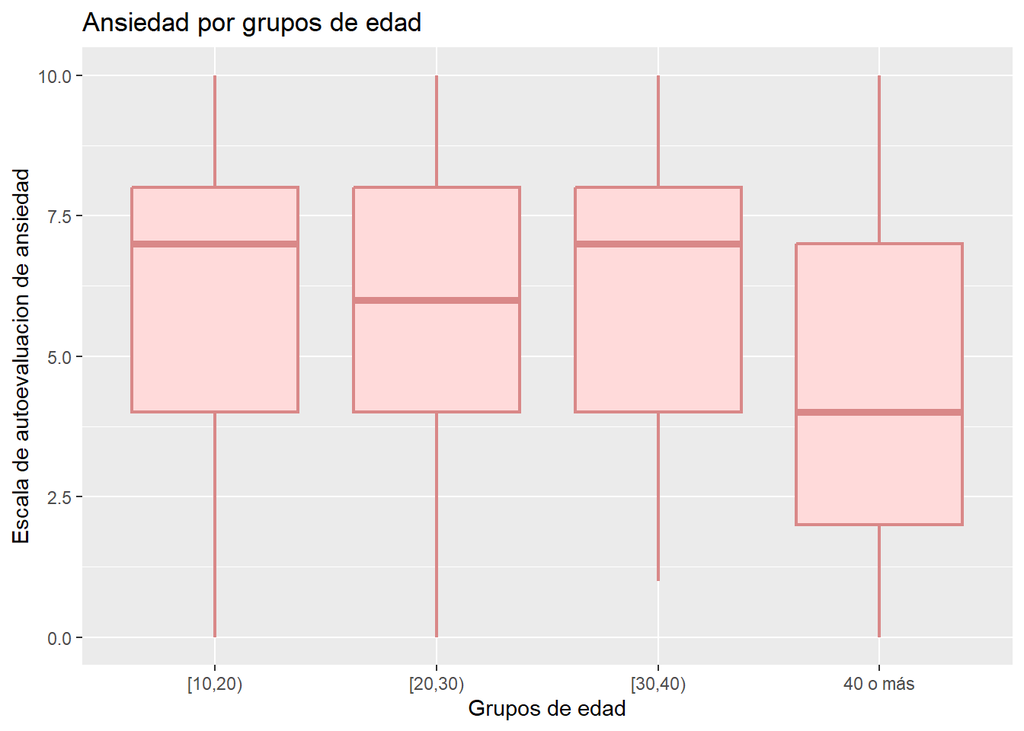

```r
ggplot(datosEdad,aes(x=GrupoEdad,y=ansiedad))+geom_boxplot(fill = "#FFDADA", color = "#D98888", linewidth = 0.8)+labs(
  title="Ansiedad por grupos de edad",
  x="Grupos de edad",
  y="Escala de autoevaluacion de ansiedad"
)
```

**Código**

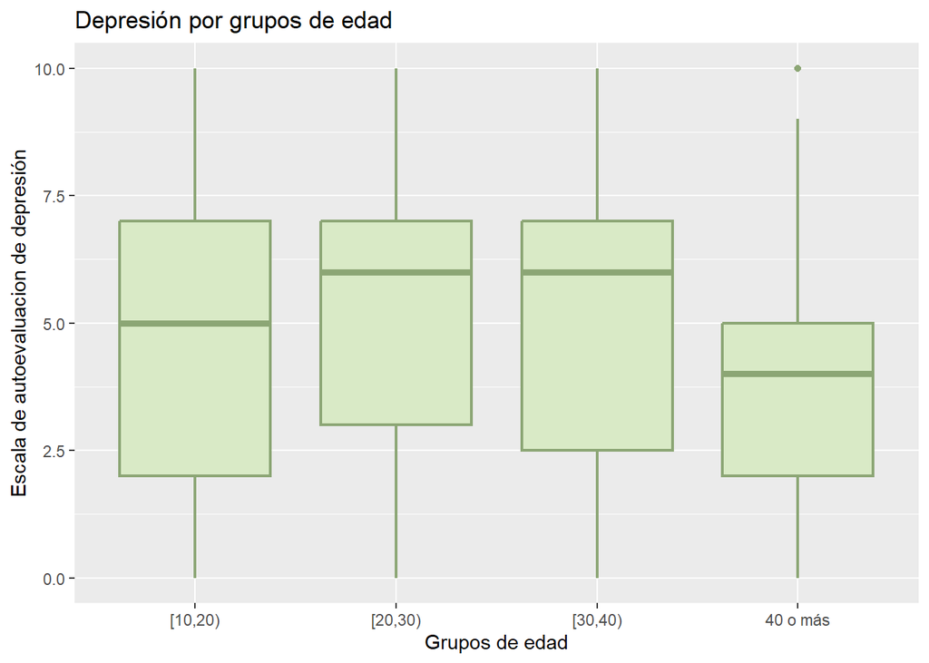

```r
ggplot(datosEdad,aes(x=GrupoEdad,y=depresion))+geom_boxplot(fill = "#D9EAC6", color = "#8CA675", linewidth = 0.8)+labs(
  title="Depresión por grupos de edad",
  x="Grupos de edad",
  y="Escala de autoevaluacion de depresión"
)
```

**Código**

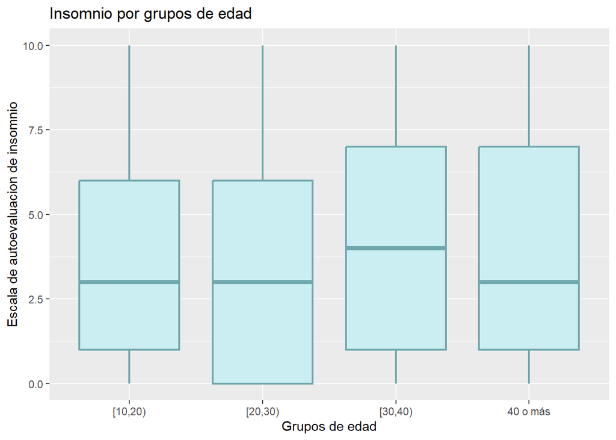

```r
ggplot(datosEdad,aes(x=GrupoEdad,y=insomnio))+geom_boxplot(fill = "#CAEEF1", color = "#6FA8AD", linewidth = 0.8)+labs(
  title="Insomnio por grupos de edad",
  x="Grupos de edad",
  y="Escala de autoevaluacion de insomnio"
)
```

**Código**

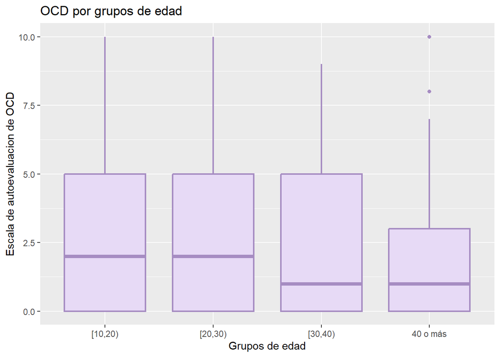

```r
ggplot(datosEdad,aes(x=GrupoEdad,y=ocd))+geom_boxplot(fill = "#E7DAF6", color = "#A68CC2", linewidth = 0.8)+labs(
  title="OCD por grupos de edad",
  x="Grupos de edad",
  y="Escala de autoevaluacion de OCD"
)
```

**Código**

```r
datosdensidad <- datosEdad %>%
  pivot_longer(
    cols = c(ansiedad, depresion, ocd, insomnio),
    names_to = "Trastorno",
    values_to = "Escala de autoevaluacion"
  )
```

**Resultado del ANOVA y boxplot:** A partir de los resultados del análisis de la varianza (ANOVA), se concluye que sí existen diferencias estadísticamente significativas en los niveles de algunas de las enfermedades mentales entre los diferentes grupos de edad.

En primer lugar, encontramos la ansiedad y la depresión con un p-valor significativamente inferior al 0.05 incluso a 0.01 en alguno de los casos, con 0.0306 y 0.00961 respectivamente, confirmando que la edad es un factor que influye de manera relevante en la autoevaluación de estos trastornos. Por otro lado, se tiene el OCD y el insomnio con un p-valor por encima de 0.05 con 0.316 y 0.346 respectivamente por lo que estos no muestran evidencia estadística suficiente para confirmar que sus niveles afecten en la muestra.

Relacionando estos análisis con los boxplot adjuntos y con las tablas hechas con la función Tukey, observamos que las diferencias estadísticamente significativas son entre los grupos más jóvenes y los mayores de 40 ya que como observamos en el caso de la ansiedad el p-valor comparando los grupos inferiores a 40 y los superiores es inferior a 0.05 en la mayoría de los casos:

- [10,20) frente a 40 o más: 0.0229138
- [20,30) frente a 40 o más: 0.0301199

Esto mismo podemos relacionarlo con el boxplot de la ansiedad puesto que como vemos las medianas hasta los 40 años se mantienen estables mostrando un drástico descenso a partir de estos. Continuando con el estudio Tukey, en la depresión vemos que ocurre algo diferente, entre las edades más tempranas existe un p-valor que indica la significancia estadística, al igual que la comparación entre los grupos de 20 y 30 con los mayores a 40:

- [20,30) frente a [10,20): 0.0472601
- [20,30) frente a 40 o más: 0.0299882

De nuevo en el boxplot observamos que las edades donde menor mediana existe y mayor diferencia hay entre el resto de edades son los que se encuentran entre 10 y 20 y los mayores de 40. Para terminar, las últimas dos enfermedades dan como resultado boxplot donde la mediana entre las edades es bastante similar, sobre todo en el caso del insomnio, y donde se podría encontrar una reducción de mediana más significativa aparentemente sería en el OCD a partir de los treinta.

**Código**

```r
datosEdad %>% group_by(GrupoEdad)%>% summarise(
  n=n(),
  Ansiedad=mean(ansiedad,na.rm=TRUE),
  Depresion=mean(depresion,na.rm=TRUE),
  OCD=mean(ocd,na.rm=TRUE),
  Insomnio=mean(insomnio,na.rm=TRUE)
)
```

```
# A tibble: 4 × 6
  GrupoEdad     n Ansiedad Depresion   OCD Insomnio
  <chr>     <int>    <dbl>     <dbl> <dbl>    <dbl>
1 40 o más     29     4.38      3.72  1.83     4
2 [10,20)     177     5.96      4.52  2.77     3.44
3 [20,30)     137     5.94      5.39  2.93     3.29
4 [30,40)      39     6.10      5.18  2.77     4.15
```

**Resultado de la tabla de medias:** Siguiendo con el análisis, en esta tabla resumen se encuentran las medias por edad en las diferentes enfermedades mentales. En primer lugar, en la ansiedad se observa una semejanza en las medias encontrándose entre (5,94-6,10) hasta los cuarenta donde existe una reducción significativa de este valor a 4,38. Análogamente, se encuentra la depresión, en la que hasta los 40 se mantiene una media estable entre 4,51 y 5,38, disminuyendo en la edad adulta a 3,72. Siguiendo este patrón es encuentra el OCD con una disminución significativa de la media a 1,83 a partir de los cuarenta, mientras que en edades anteriores se había mantenido entre 2,76 y 2,94. Por último, el insomnio en el que se observa que edades más temparanas entre los 10 y 30 años se mantiene estable, y a partir de los 30 aparece un aumento significativo de las medias llegando hasta 4,15.

**Resultado del gráfico de densidad:** A continuación, visualizaremos un gráfico de densidad que nos muestra la distribución de las enfermedades de salud mental por grupos de edad. Con estos resultados vemos como la ansiedad (anaranjado) muestra un pico alto en las edades hasta cuarenta años, sobre todo muestra un pico pronunciado en valores más elevados. La depresión (verdoso), al igual que la ansiedad muestra una mayor concentración entre los 10 y 30 años, mientras que a partir de los 40 muestra un desplazamiento claro hacia valores más bajos. Por otro lado, el OCD (morado) señala en todas las edades una curva de densidad alta en valores más bajos, coincidiendo con el valor encontrado con el ANOVA puesto que no había diferencias significativas. Por último, se tiene el insomnio(azulado), que se mantiene estable aunque muestra una densidad mayor en valores más bajos sobre todo en edades tempranas

**Código**

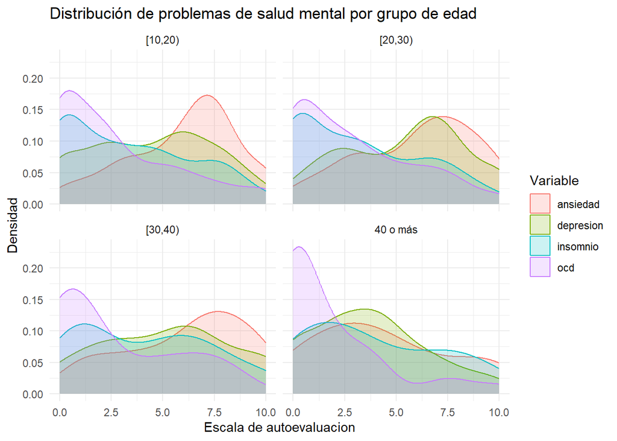

```r
ggplot(datosdensidad, aes(x = `Escala de autoevaluacion`, colour = Trastorno, fill = Trastorno)) +
  geom_density(alpha = 0.2, na.rm = TRUE) +
  facet_wrap(~ GrupoEdad) +
  labs(
    title = "Distribución de problemas de salud mental por grupo de edad",
    x = "Escala de autoevaluacion",
    y = "Densidad",
    colour = "Variable",
    fill = "Variable"
  ) +
  theme_minimal()
```

- **¿Predomina alguna edad con algún tipo de enfermedad mental?**

**Código**

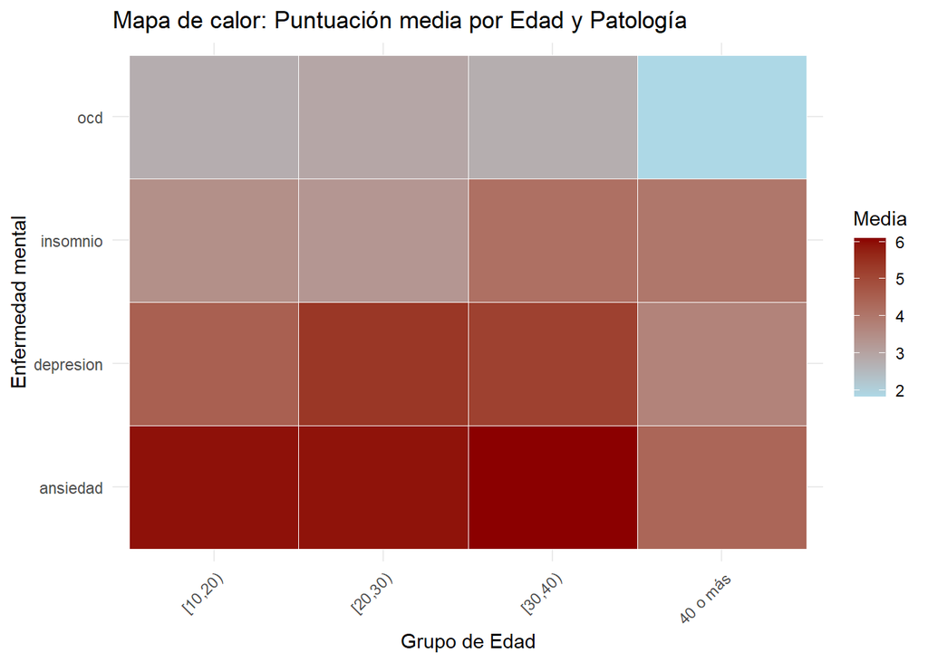

```r
# Pasamos los datos a formato largo para facilitar la comparación por enfermedad
datos_largo <- datosEdad %>%
  pivot_longer(cols = c(ansiedad, depresion, insomnio, ocd),
               names_to = "Enfermedad", values_to = "Puntuacion")
# Calculamos la puntuación media de cada enfermedad por cada grupo de edad
datos_medias <- datos_largo %>%
  group_by(GrupoEdad, Enfermedad) %>%
  summarise(Media_Puntuacion = mean(Puntuacion, na.rm = TRUE), .groups = 'drop')

# Generamos el mapa de calor
ggplot(datos_medias, aes(x = GrupoEdad, y = Enfermedad, fill = Media_Puntuacion)) +
  geom_tile(color = "white") +
  scale_fill_gradient(low = "lightblue", high = "darkred") +
  theme_minimal() +
  labs(title = "Mapa de calor: Puntuación media por Edad y Patología",
       x = "Grupo de Edad", y = "Enfermedad mental", fill = "Media") +
  theme(axis.text.x = element_text(angle = 45, hjust = 1))
```

A partir del mapa de calor, se concluye que la ansiedad es la patología con mayor intensidad y predominio en la muestra, registrando las puntuaciones medias más altas (tonos rojo oscuro) especialmente en los grupos de edad más jóvenes, desde los 10 hasta los 40 años. La depresión se sitúa en un segundo plano con valores también elevados en esos mismos tramos de edad. Por el contrario, el insomnio y el TOC muestran colores más claros, lo que indica que sus puntuaciones medias de autoevaluación son considerablemente más bajas en la mayoría de los grupos.

**- ¿Existe algún género musical que tenga efecto positivo en alguna de las enfermedades mentales? ¿Cuáles son los géneros más/menos escuchados entre la gente con depresión/ansiedad/ocd/insomnia?**

Estas preguntas pueden ser interesantes de investigar a la vez ya que en ambas vamos a explorar las variables frecuencias y nos pueden ayudar a no caer en deducciones precipitadas.

Empezamos con la pregunta, ¿Existe algún género musical que tenga efecto positivo en alguna de las enfermedades mentales?

Para responder a esta pregunta vamos a tomar a las personas que indicaron en la encuesta que la música tiene efecto positivo.

Para este análisis vamos a tomar una métrica en la que en las variables de frecuencia el salto entre cada escalón de la categoría es igual. En otras palabras, la distancia entre “Never” y “Rarely” es la misma que entre “Frequently” y “Very Frequently”, siendo igual entre el resto de escalones.

**Código**

```r
#Filtramos a las personas que indican que la música tiene un efecto positivo ("Improve")
# y calcular la media de escucha de cada género en ese grupo
efecto_positivo_generos <- datos_train_imp %>%
  filter(efectos == "Improve") %>%
  select(starts_with("f_")) %>%
  mutate(across(everything(), ~ case_when(
    .x == "Never" ~ 0,
    .x == "Rarely" ~ 1,
    .x == "Sometimes" ~ 2,
    .x == "Frequently" ~ 3,
    .x == "Very frequently" ~ 4,
    TRUE ~ NA_real_
  ))) %>%
  summarise(across(everything(), ~ mean(.x, na.rm = TRUE))) %>%
  pivot_longer(everything(), names_to = "genero", values_to = "media_escucha") %>%
  arrange(desc(media_escucha))

efecto_positivo_generos
```

```
# A tibble: 16 × 2
   genero    media_escucha
   <chr>             <dbl>
 1 f_pop             2.52
 2 f_rock            2.41
 3 f_rap             1.66
 4 f_hiphop          1.65
 5 f_ryb             1.61
 6 f_clasica         1.54
 7 f_vgm             1.45
 8 f_metal           1.41
 9 f_lofi            1.22
10 f_jazz            1.16
11 f_folk            1.11
12 f_edm             1.10
13 f_kpop            0.908
14 f_country         0.883
15 f_latin           0.678
16 f_gospel          0.417
```

**Código**

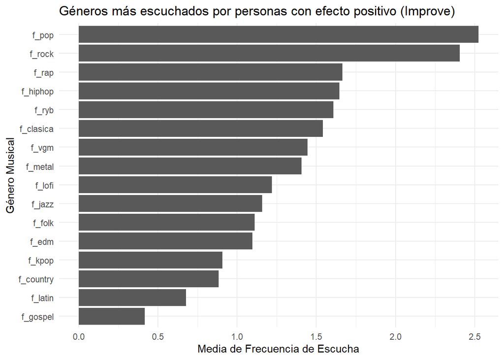

```r
ggplot(efecto_positivo_generos, aes(x = reorder(genero, media_escucha), y = media_escucha)) +
  geom_col(show.legend = FALSE) +
  coord_flip() +
  labs(
    title = "Géneros más escuchados por personas con efecto positivo (Improve)",
    x = "Género Musical",
    y = "Media de Frecuencia de Escucha"
  ) +
  theme_minimal()
```

Al analizar si existe un género musical asociado a un efecto positivo en la salud mental, se observa de forma global que la gran mayoría de los encuestados que experimentan una mejoría (*Improve*) consumen habitualmente géneros como el Rock y el Pop. No obstante, esto puede guardar una estrecha relación con que son también los géneros más habituales de la muestra como género favorito.

Vamos ahora a analizar las frecuecias de géneros de música por problema de salud mental, teniendo como objetivo las personas que tengan un índice bajo de autopercepción del transtorno correspondiente.

¿Como fijamos que es alto o bajo para cada transtorno? Para ello vamos a tener en cuenta en conjunto, la gravedad de la enfermedad y la media de los datos de autopercepción.

**Código**

```r
cat("Insomnio")
```

```
Insomnio
```

**Código**

```r
table(datos_train_imp$insomnio, useNA = 'always')
```

```
   0    1    2    3    4    5    6    7    8    9   10 <NA>
  90   42   41   37   34   31   24   31   29   11   12    0
```

**Código**

```r
media_insomnio_train <- mean(datos_train_imp$insomnio, na.rm = TRUE)
mediana_insomnio_train<- median(datos_train_imp$insomnio, na.rm = TRUE)
cat("La media es", media_insomnio_train, "\n")
```

```
La media es 3.502618
```

**Código**

```r
cat("La mediana es",mediana_insomnio_train, "\n")
```

```
La mediana es 3
```

**Código**

```r
cat("depresion")
```

```
depresion
```

**Código**

```r
table(datos_train_imp$depresion, useNA = 'always')
```

```
   0    1    2    3  3.5    4    5    6    7    8    9   10 <NA>
  40   18   47   34    1   32   31   55   45   37   14   28    0
```

**Código**

```r
media_depresion_train <- mean(datos_train_imp$depresion, na.rm = TRUE)
mediana_depresion_train<- median(datos_train_imp$depresion, na.rm = TRUE)
cat("La media es", media_depresion_train, "\n")
```

```
La media es 4.836387
```

**Código**

```r
cat("La mediana es",mediana_depresion_train, "\n")
```

```
La mediana es 5
```

**Código**

```r
cat("ansiedad")
```

```
ansiedad
```

**Código**

```r
table(datos_train_imp$ansiedad, useNA = 'always')
```

```
   0    1    2    3    4    5    6    7  7.5    8    9   10 <NA>
  15   20   20   37   28   29   47   64    1   56   29   36    0
```

**Código**

```r
media_ansiedad_train <- mean(datos_train_imp$ansiedad, na.rm = TRUE)
mediana_ansiedad_train<- median(datos_train_imp$ansiedad, na.rm = TRUE)
cat("La media es", media_ansiedad_train, "\n")
```

```
La media es 5.849476
```

**Código**

```r
cat("La mediana es",mediana_ansiedad_train, "\n")
```

```
La mediana es 6
```

**Código**

```r
cat("ocd")
```

```
ocd
```

**Código**

```r
table(datos_train_imp$ocd, useNA = 'always')
```

```
   0    1    2    3    4    5    6    7    8  8.5    9   10 <NA>
 118   52   54   34   24   25   20   20   17    1    4   13    0
```

**Código**

```r
media_ocd_train <- mean(datos_train_imp$ocd, na.rm = TRUE)
mediana_ocd_train<- median(datos_train_imp$ocd, na.rm = TRUE)
cat("La media es", media_ocd_train, "\n")
```

```
La media es 2.757853
```

**Código**

```r
cat("La mediana es",mediana_ocd_train, "\n")
```

```
La mediana es 2
```

El insomnio tomaremos como valor medio el 4, siendo un nivel “bajo” desde 3 para abajo y alto de 5 para arriba.

La depresión como alto a partir de 5, a pesar de que la media salga 4,8. Siendo el punto medio el 4 y bajo desde 3 hasta 0.

La ansiedad, tomaremos como alto de 6 en adelante, 5 como punto medio y bajo de 4 hasta 0.

El ocd, tomaremos como punto medio el 3, alto de 4 en adelante y bajo de 2 para abajo.

Estamos tomando estas referencias, como punto inicial y en caso de ver en posteriores fases del proyecto que hayan sido demasiado severas o restrictivas, podremos corregirnos. Por ahora serán nuestras referencias.

| Enfermedad | Bajo | Punto medio | Alto |
| --- | --- | --- | --- |
| Insomnio | 0-3 | 4 | 5-10 |
| Depresion | 0-3 | 4 | 5-10 |
| Ansiedad | 0-4 | 5 | 6-10 |
| OCD | 0-2 | 3 | 4-10 |

**Código**

```r
ansiedad_baja_generos <- datos_train_imp %>%
  filter(ansiedad <= 4) %>%
  select(starts_with("f_")) %>%
  mutate(across(everything(), ~ case_when(
    .x == "Never" ~ 0,
    .x == "Rarely" ~ 1,
    .x == "Sometimes" ~ 2,
    .x == "Frequently" ~ 3,
    .x == "Very frequently" ~ 4,
    TRUE ~ NA_real_
  ))) %>%
  summarise(across(everything(), ~ mean(.x, na.rm = TRUE))) %>%
  pivot_longer(everything(), names_to = "genero", values_to = "media_ansiedad_baja") %>%
  arrange(desc(media_ansiedad_baja))

ansiedad_baja_generos
```

```
# A tibble: 16 × 2
   genero    media_ansiedad_baja
   <chr>                   <dbl>
 1 f_pop                   2.29
 2 f_rock                  2.24
 3 f_clasica               1.64
 4 f_hiphop                1.49
 5 f_ryb                   1.46
 6 f_rap                   1.46
 7 f_metal                 1.32
 8 f_vgm                   1.26
 9 f_jazz                  1.14
10 f_lofi                  1.13
11 f_edm                   1.08
12 f_folk                  0.925
13 f_country               0.783
14 f_kpop                  0.75
15 f_latin                 0.575
16 f_gospel                0.4
```

**Código**

```r
depresion_baja_generos <- datos_train_imp %>%
  filter(depresion <= 3) %>%
  select(starts_with("f_")) %>%
  mutate(across(everything(), ~ case_when(
    .x == "Never" ~ 0,
    .x == "Rarely" ~ 1,
    .x == "Sometimes" ~ 2,
    .x == "Frequently" ~ 3,
    .x == "Very frequently" ~ 4,
    TRUE ~ NA_real_
  ))) %>%
  summarise(across(everything(), ~ mean(.x, na.rm = TRUE))) %>%
  pivot_longer(everything(), names_to = "genero", values_to = "media_depresion_baja") %>%
  arrange(desc(media_depresion_baja))

depresion_baja_generos
```

```
# A tibble: 16 × 2
   genero    media_depresion_baja
   <chr>                    <dbl>
 1 f_pop                    2.28
 2 f_rock                   2.25
 3 f_clasica                1.48
 4 f_hiphop                 1.46
 5 f_rap                    1.46
 6 f_metal                  1.35
 7 f_ryb                    1.34
 8 f_vgm                    1.29
 9 f_lofi                   1.09
10 f_jazz                   1
11 f_edm                    0.950
12 f_folk                   0.921
13 f_kpop                   0.885
14 f_country                0.827
15 f_latin                  0.540
16 f_gospel                 0.374
```

**Código**

```r
ocd_bajo_generos <- datos_train_imp %>%
  filter(ocd <= 2) %>%
  select(starts_with("f_")) %>%
  mutate(across(everything(), ~ case_when(
    .x == "Never" ~ 0,
    .x == "Rarely" ~ 1,
    .x == "Sometimes" ~ 2,
    .x == "Frequently" ~ 3,
    .x == "Very frequently" ~ 4,
    TRUE ~ NA_real_
  ))) %>%
  summarise(across(everything(), ~ mean(.x, na.rm = TRUE))) %>%
  pivot_longer(everything(), names_to = "genero", values_to = "media_ocd_bajo") %>%
  arrange(desc(media_ocd_bajo))

ocd_bajo_generos
```

```
# A tibble: 16 × 2
   genero    media_ocd_bajo
   <chr>              <dbl>
 1 f_pop              2.49
 2 f_rock             2.46
 3 f_hiphop           1.57
 4 f_rap              1.57
 5 f_clasica          1.56
 6 f_metal            1.46
 7 f_ryb              1.44
 8 f_vgm              1.44
 9 f_jazz             1.13
10 f_lofi             1.11
11 f_folk             1.06
12 f_edm              1.04
13 f_country          0.821
14 f_kpop             0.812
15 f_latin            0.665
16 f_gospel           0.366
```

**Código**

```r
insomnio_bajo_generos <- datos_train_imp %>%
  filter(insomnio <= 3) %>%
  select(starts_with("f_")) %>%
  mutate(across(everything(), ~ case_when(
    .x == "Never" ~ 0,
    .x == "Rarely" ~ 1,
    .x == "Sometimes" ~ 2,
    .x == "Frequently" ~ 3,
    .x == "Very frequently" ~ 4,
    TRUE ~ NA_real_
  ))) %>%
  summarise(across(everything(), ~ mean(.x, na.rm = TRUE))) %>%
  pivot_longer(everything(), names_to = "genero", values_to = "media_insomnio_bajo") %>%
  arrange(desc(media_insomnio_bajo))

insomnio_bajo_generos
```

```
# A tibble: 16 × 2
   genero    media_insomnio_bajo
   <chr>                   <dbl>
 1 f_pop                   2.51
 2 f_rock                  2.35
 3 f_rap                   1.57
 4 f_hiphop                1.54
 5 f_clasica               1.42
 6 f_ryb                   1.42
 7 f_vgm                   1.32
 8 f_metal                 1.31
 9 f_lofi                  1.10
10 f_jazz                  1.06
11 f_folk                  1.03
12 f_edm                   1.02
13 f_country               0.910
14 f_kpop                  0.838
15 f_latin                 0.581
16 f_gospel                0.410
```

Vemos con este análisis un pequeño patron, en el que las frecuencias de escucha más altas entre las personas que hemos considerado que están en un rango bajo de los problemas de salud mental, son el género de pop y rock, a primera vista.

Aun así, quizá que esta media de frecuencias sea alta, se deba a que son géneros más populares. Por ello es momento de tratar la segunda pregunta.

¿Cuáles son los géneros más/menos escuchados entre la gente con depresión/ansiedad/ocd/insomnia?

Vamos a fijarnos ahora en las personas con un rango que consideramos alto en la autopercepción de la enfermedad.

**Código**

```r
#Función auxiliar para traducir las frecuencias de texto a valores numéricos (0 a 4), considerando la métrica
#de un escalonado uniforme entre niveles.
convertir_freq <- function(x) {
  case_when(
    x == "Never" ~ 0,
    x == "Rarely" ~ 1,
    x == "Sometimes" ~ 2,
    x == "Frequently" ~ 3,
    x == "Very frequently" ~ 4,
    TRUE ~ NA_real_
  )
}

# --- PERSONAS CON ANSIEDAD ALTA---
ranking_ansiedad <- datos_train_imp %>%
  filter(ansiedad >= 6) %>%
  select(starts_with("f_")) %>%
  mutate(across(everything(), convertir_freq)) %>%
  summarise(across(everything(), ~ mean(.x, na.rm = TRUE))) %>%
  pivot_longer(everything(), names_to = "genero", values_to = "media_escucha") %>%
  arrange(desc(media_escucha))

print("Ranking en Ansiedad Alta:")
```

```
[1] "Ranking en Ansiedad Alta:"
```

**Código**

```r
print(ranking_ansiedad)
```

```
# A tibble: 16 × 2
   genero    media_escucha
   <chr>             <dbl>
 1 f_pop             2.58
 2 f_rock            2.56
 3 f_rap             1.68
 4 f_hiphop          1.68
 5 f_ryb             1.57
 6 f_vgm             1.53
 7 f_metal           1.51
 8 f_clasica         1.46
 9 f_lofi            1.21
10 f_folk            1.15
11 f_edm             1.14
12 f_jazz            1.13
13 f_country         0.927
14 f_kpop            0.897
15 f_latin           0.704
16 f_gospel          0.343
```

**Código**

```r
# --- PERSONAS CON DEPRESIÓN ALTA ---
ranking_depresion <- datos_train_imp %>%
  filter(depresion >= 5) %>%
  select(starts_with("f_")) %>%
  mutate(across(everything(), convertir_freq)) %>%
  summarise(across(everything(), ~ mean(.x, na.rm = TRUE))) %>%
  pivot_longer(everything(), names_to = "genero", values_to = "media_escucha") %>%
  arrange(desc(media_escucha))

print("Ranking en Depresión Alta:")
```

```
[1] "Ranking en Depresión Alta:"
```

**Código**

```r
print(ranking_depresion)
```

```
# A tibble: 16 × 2
   genero    media_escucha
   <chr>             <dbl>
 1 f_rock            2.62
 2 f_pop             2.54
 3 f_rap             1.74
 4 f_hiphop          1.70
 5 f_vgm             1.60
 6 f_metal           1.60
 7 f_ryb             1.60
 8 f_clasica         1.52
 9 f_edm             1.28
10 f_lofi            1.21
11 f_folk            1.16
12 f_jazz            1.16
13 f_country         0.876
14 f_kpop            0.795
15 f_latin           0.719
16 f_gospel          0.333
```

**Código**

```r
# --- PERSONAS CON INSOMNIO ALTO  ---
ranking_insomnio <- datos_train_imp %>%
  filter(insomnio >=5) %>%
  select(starts_with("f_")) %>%
  mutate(across(everything(), convertir_freq)) %>%
  summarise(across(everything(), ~ mean(.x, na.rm = TRUE))) %>%
  pivot_longer(everything(), names_to = "genero", values_to = "media_escucha") %>%
  arrange(desc(media_escucha))

print("Ranking en Insomnio Alto:")
```

```
[1] "Ranking en Insomnio Alto:"
```

**Código**

```r
print(ranking_insomnio)
```

```
# A tibble: 16 × 2
   genero    media_escucha
   <chr>             <dbl>
 1 f_rock            2.64
 2 f_pop             2.48
 3 f_metal           1.76
 4 f_hiphop          1.69
 5 f_rap             1.69
 6 f_ryb             1.67
 7 f_vgm             1.63
 8 f_clasica         1.59
 9 f_edm             1.36
10 f_lofi            1.30
11 f_jazz            1.21
12 f_folk            1.17
13 f_kpop            0.913
14 f_country         0.819
15 f_latin           0.783
16 f_gospel          0.341
```

**Código**

```r
# ---PERSONAS CON OCD ALTO ---
ranking_ocd <- datos_train_imp %>%
  filter(ocd >= 4) %>%
  select(starts_with("f_")) %>%
  mutate(across(everything(), convertir_freq)) %>%
  summarise(across(everything(), ~ mean(.x, na.rm = TRUE))) %>%
  pivot_longer(everything(), names_to = "genero", values_to = "media_escucha") %>%
  arrange(desc(media_escucha))

print("Ranking en OCD Alto:")
```

```
[1] "Ranking en OCD Alto:"
```

**Código**

```r
print(ranking_ocd)
```

```
# A tibble: 16 × 2
   genero    media_escucha
   <chr>             <dbl>
 1 f_pop             2.51
 2 f_rock            2.47
 3 f_metal           1.68
 4 f_rap             1.65
 5 f_hiphop          1.63
 6 f_ryb             1.61
 7 f_vgm             1.48
 8 f_clasica         1.45
 9 f_edm             1.34
10 f_lofi            1.28
11 f_folk            1.10
12 f_jazz            1.10
13 f_kpop            1
14 f_country         0.984
15 f_latin           0.621
16 f_gospel          0.379
```

Al analizar los hábitos de escucha específicos de los subgrupos con puntuaciones elevadas en patologías como ansiedad, depresión, insomnio y OCD, se observa que no existe una diferencia radical respecto al consumo general de la muestra. Los géneros más escuchados de manera habitual por estas personas siguen siendo el Rock y el Pop. Por el contrario, los géneros menos escuchados coinciden en los niveles más bajos de la escala, destacando el Gospel y el Latin.

Por lo que por ahora, no podemos sacar una conclusión de que un género particular cause un efecto positivo de primera mano. En etapas posteriores con combinación de variables y técnicas como el clustering, podremos indagar más a fondo en estos posibles beneficios.

Una vez se tiene una exploración global de los datos, enfocaremos nuestro estudio en la predicción que buscamos analizar. Observamos que pueden existir variables que no nos proporcionen información al *target* como sería la plataforma e incluso el género favorito u horas de escucha.

**¿Es relevante saber la plataforma con la que escuchan música de cara a nuestra variable respuesta?**

**Código**

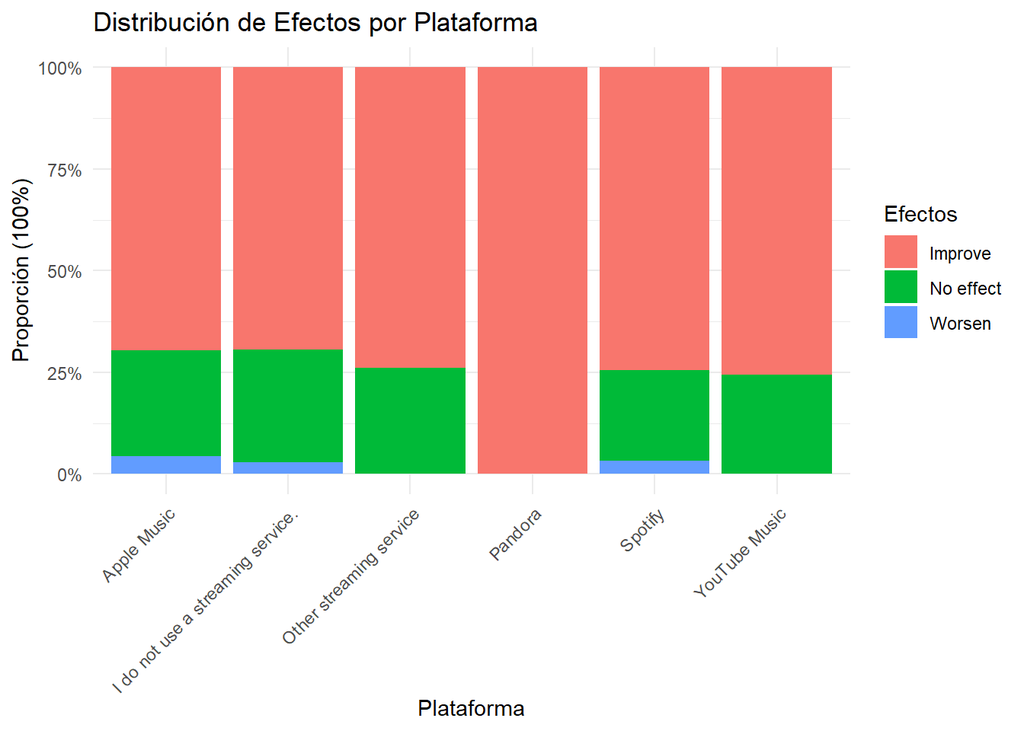

```r
ggplot(datos_train_imp, aes(x = plataforma, fill = efectos)) +
  geom_bar(position = "fill") +
  scale_y_continuous(labels = scales::percent) +
  labs(
    title = "Distribución de Efectos por Plataforma",
    x = "Plataforma",
    y = "Proporción (100%)",
    fill = "Efectos"
  ) +
  theme_minimal() +
  theme(
    axis.text.x = element_text(angle = 45, hjust = 1, vjust = 1)
  )
```

Por lo que podemos apreciar en el gráfico, todas las plataformas tienen proporciones similares. Pandora resalta por solo tener improve. Veamos cuantas muestras tenemos con pandora para verificar que no se deba una cantidad reducida de muestras. Y de paso comprobemos el resto de categorias.

**Código**

```r
table(datos_train_imp$plataforma)
```

```
                      Apple Music I do not use a streaming service.
                               23                                36
          Other streaming service                           Pandora
                               23                                 5
                          Spotify                     YouTube Music
                              254                                41
```

Vemos que efectivamente pandora tiene solo 5 instancias, por lo que seguramente se deba a ello. Además, se aprecia que Spotify es mucho más usada que las otras platadormas, hasta el punto que es superior a todas las demás juntas.

Juntemoslas para comparar Spotify a las demás, para ver si el gráfico de barras entre Spotify y las demás se parecen más entre si.

**Código**

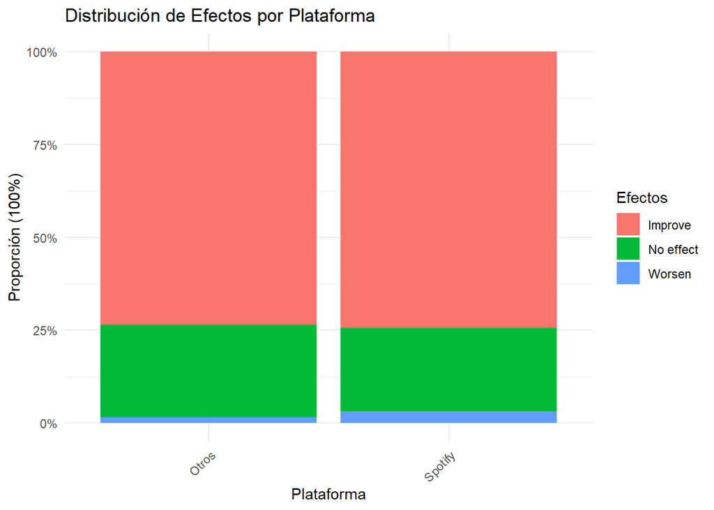

```r
datos_train_agrupplat <- datos_train_imp

datos_train_agrupplat$plataforma <- ifelse(
  datos_train_agrupplat$plataforma == "Spotify",
  "Spotify",
  "Otros"
)
ggplot(datos_train_agrupplat, aes(x = plataforma, fill = efectos)) +
  geom_bar(position = "fill") +
  scale_y_continuous(labels = scales::percent) +
  labs(
    title = "Distribución de Efectos por Plataforma",
    x = "Plataforma",
    y = "Proporción (100%)",
    fill = "Efectos"
  ) +
  theme_minimal() +
  theme(
    axis.text.x = element_text(angle = 45, hjust = 1, vjust = 1)
  )
```

Como podemos apreciar al agruparlo, las distribuciones son identicas prácticamente.

También vamos a usar el test chi cuadrado con todas las categorias y luego probaremos con la versión de dos categorias solo.

La prueba de chi-cuadrado es una prueba estadística que sirve para determinar si existe una asociación significativa entre variables cualitativas o categóricas comparando lo que se ha observado en la realidad con lo que se esperaría obtener por azar. En este test la hipótesis nula es que las variables son independientes o no tienen relación.

**Código**

```r
chisq.test(table(datos_train_imp$plataforma, datos_train_imp$efectos))
```

```
    Pearson's Chi-squared test

data:  table(datos_train_imp$plataforma, datos_train_imp$efectos)
X-squared = 4.7147, df = 10, p-value = 0.9094
```

El p-valor es de 0,9, por lo que no podemos rechazar la hipótesis nula de que sean independientes, por lo que parece la variable plataforma no influye en nuestra variable efecto.

Aun así como nos sale en el test chi cuadrado un warning en el que puede ser incorrecto, debido a que algunas muestras en algunas categorías no son suficientes, probaremos con el test de fisher que funciona similar.

**Código**

```r
fisher.test(table(datos_train_imp$plataforma, datos_train_imp$efectos), simulate.p.value = TRUE)
```

```
    Fisher's Exact Test for Count Data with simulated p-value (based on
    2000 replicates)

data:  table(datos_train_imp$plataforma, datos_train_imp$efectos)
p-value = 0.926
alternative hypothesis: two.sided
```

El resultado de este test, reafirma lo visto con el test chi-cuadrado.

Probemos ahora con solo dos categorias.

**Código**

```r
chisq.test(table(datos_train_agrupplat$plataforma, datos_train_agrupplat$efectos))
```

```
    Pearson's Chi-squared test

data:  table(datos_train_agrupplat$plataforma, datos_train_agrupplat$efectos)
X-squared = 1.069, df = 2, p-value = 0.586
```

**Código**

```r
fisher.test(table(datos_train_agrupplat$plataforma, datos_train_agrupplat$efectos), simulate.p.value = TRUE)
```

```
    Fisher's Exact Test for Count Data with simulated p-value (based on
    2000 replicates)

data:  table(datos_train_agrupplat$plataforma, datos_train_agrupplat$efectos)
p-value = 0.6312
alternative hypothesis: two.sided
```

Aunque el p-valor de los test, es menor en este caso para ambos test, sigue siendo suficiente alto como para no poder rechazar la hipótesis nula.

Habiendo visto estas pruebas, parece ser que la variable plataforma no aporta a la hora de ver si un paciente mejora o no en nuestro estudio. Por lo que quizá sea de nuestro interés eliminarla en la próxima etapa del proyecto.

**¿Que tan relevante es el género favorito por si solo?**

**Código**

```r
#Porcentaje de efecto positivo por genero_fav
efecto_por_genero <- datos_train_imp %>%
  group_by(genero_fav) %>%
  summarise(
    total = n(),
    mejora = sum(efectos == "Improve", na.rm = TRUE),
    pct_mejora = round((mejora / total) * 100, 2)
  ) %>%
  arrange(desc(pct_mejora))

print(efecto_por_genero)
```

```
# A tibble: 14 × 4
   genero_fav       total mejora pct_mejora
   <fct>            <int>  <int>      <dbl>
 1 Folk                 8      8      100
 2 Otros géneros        8      8      100
 3 Hip hop             18     18      100
 4 K pop               15     13       86.7
 5 Jazz                12     10       83.3
 6 Rap                 14     11       78.6
 7 Classical           27     21       77.8
 8 Pop                 64     49       76.6
 9 Country             16     12       75
10 EDM                 20     15       75
11 Metal               52     39       75
12 R&B                 20     13       65
13 Rock                83     52       62.6
14 Video game music    25     14       56
```

**Código**

```r
#Prueba estadística de Chi-cuadrado para ver si la relación es significativa
tabla_genfav <- table(datos_train_imp$genero_fav, datos_train_imp$efectos)
chisq.test(tabla_genfav)
```

```
    Pearson's Chi-squared test

data:  tabla_genfav
X-squared = 37.069, df = 26, p-value = 0.0737
```

**Código**

```r
fisher.test(tabla_genfav, simulate.p.value = TRUE)
```

```
    Fisher's Exact Test for Count Data with simulated p-value (based on
    2000 replicates)

data:  tabla_genfav
p-value = 0.07396
alternative hypothesis: two.sided
```

Al realizar el test chi cuadrado, vemos que tenemos un valor de 37 con 26 grados de libertad lo que no es especialmente alto, por tanto la diferencia entre lo observado y lo esperado aún puede deberse al azar.

El p-valor tanto en la prueba chi-cuadrado como la de fisher, esta entre 0,07 y cerca de 0,08, aunque con esto no podemos rechazar la hipótesis nula de que no existe asociación entre el género musical favorito y el efecto observado, si que está en el límite de poder rechazarse.

**Código**

```r
efecto_genero_Ansiedad <- datos_train_imp %>%
  group_by(genero_fav) %>%
  summarise(
    Media_Ansiedad = round(mean(ansiedad, na.rm = TRUE), 2),
    Total_Personas = n()
  ) %>%
  arrange(desc(Media_Ansiedad))
efecto_genero_Ansiedad
```

```
# A tibble: 14 × 3
   genero_fav       Media_Ansiedad Total_Personas
   <fct>                     <dbl>          <int>
 1 Folk                       8.5               8
 2 Jazz                       6.92             12
 3 K pop                      6.73             15
 4 Hip hop                    6.44             18
 5 Country                    6.12             16
 6 Otros géneros              6                 8
 7 Pop                        5.96             64
 8 Rock                       5.93             83
 9 Video game music           5.72             25
10 EDM                        5.65             20
11 Metal                      5.6              52
12 Rap                        5.5              14
13 R&B                        5.3              20
14 Classical                  4.33             27
```

**Código**

```r
efecto_genero_Depresion <- datos_train_imp %>%
  group_by(genero_fav) %>%
  summarise(
    Media_Depresion = round(mean(depresion, na.rm = TRUE), 2),
    Total_Personas = n()
  ) %>%
  arrange(desc(Media_Depresion))
efecto_genero_Depresion
```

```
# A tibble: 14 × 3
   genero_fav       Media_Depresion Total_Personas
   <fct>                      <dbl>          <int>
 1 Otros géneros               7.12              8
 2 Folk                        6.62              8
 3 EDM                         5.7              20
 4 Hip hop                     5.33             18
 5 Rock                        5.3              83
 6 Jazz                        5.17             12
 7 Country                     5.06             16
 8 Metal                       4.79             52
 9 Video game music            4.64             25
10 Rap                         4.5              14
11 Pop                         4.43             64
12 K pop                       4                15
13 R&B                         3.8              20
14 Classical                   3.59             27
```

**Código**

```r
efecto_genero_Insomnio <- datos_train_imp %>%
  group_by(genero_fav) %>%
  summarise(
    Media_Insomnio = round(mean(insomnio, na.rm = TRUE), 2),
    Total_Personas = n()
  ) %>%
  arrange(desc(Media_Insomnio))
efecto_genero_Insomnio
```

```
# A tibble: 14 × 3
   genero_fav       Media_Insomnio Total_Personas
   <fct>                     <dbl>          <int>
 1 Otros géneros              5.5               8
 2 Jazz                       4.83             12
 3 EDM                        4.8              20
 4 Metal                      4.27             52
 5 Folk                       3.88              8
 6 Rock                       3.54             83
 7 Video game music           3.32             25
 8 K pop                      3.2              15
 9 Pop                        3.17             64
10 R&B                        3.05             20
11 Classical                  2.89             27
12 Country                    2.69             16
13 Hip hop                    2.61             18
14 Rap                        2.14             14
```

**Código**

```r
efecto_genero_Ocd <- datos_train_imp %>%
  group_by(genero_fav) %>%
  summarise(
    Media_Ocd = round(mean(ocd, na.rm = TRUE), 2),
    Total_Personas = n()
  ) %>%
  arrange(desc(Media_Ocd))
efecto_genero_Ocd
```

```
# A tibble: 14 × 3
   genero_fav       Media_Ocd Total_Personas
   <fct>                <dbl>          <int>
 1 EDM                   3.65             20
 2 Rap                   3.5              14
 3 Jazz                  3.42             12
 4 Country               2.81             16
 5 Rock                  2.78             83
 6 K pop                 2.73             15
 7 Hip hop               2.72             18
 8 Metal                 2.63             52
 9 Pop                   2.63             64
10 Folk                  2.62              8
11 R&B                   2.6              20
12 Video game music      2.6              25
13 Classical             2.44             27
14 Otros géneros         1.88              8
```

Al analizar estas tablas de medias por género favorito, no parece que podamos sacar muchas conclusiones respecto a géneros que nos generaban dudas en las preguntas anteriores como han sido el pop y el rock. Pero sí que llama la atención que las personas cuyo género favorito es la música clásica tengan en los cuatro casos una de las 5 menores medias entre los géneros, teniendo un número de personas significativo en la muestra train. Esto también pasa con el género R&B.

Por lo que quizá la variable genero_fav, si tenga alguna relevancia en relación a los índices de autopercepción de las enfermedades.

Por tanto por ahora, teniendo en cuenta los test anteriores y estas tablas de medias, podemos decir que a pesar de que el p-valor en relación con la variable efecto, no parece ser lo más significativa posible por estar al límite, no hemos podido concluir que no esté relacionada. Viendo que hay posibles patrones como el observado con el género música clásica y los índices de autopercepción, diremos que la variable síi va a ser relevante. La medida en lo que esta variable lo sea, se verá en la siguiente etapa en donde empezaremos a reducir dimensiones y realizar clustering.

## 6 Principales hallazgos y conclusiones

A partir del análisis exploratorio del conjunto de datos sobre música y salud mental, podemos extraer los siguientes hallazgos relevantes en relación con los objetivos planteados:

   Al analizar los subgrupos con puntuaciones elevadas en ansiedad, depresión, insomnio y OCD, se observa que no existe una discrepancia respecto al consumo general: los géneros más escuchados por estos perfiles clínicos siguen siendo el Rock y el Pop.

A la hora de interpretar los resultados anteriores, es necesario tener en cuenta las siguientes limitaciones:

1. **Correlación frente a casualidad:** al tratarse de un estudio observacional los datos permiten identificar tendencias de consumo y correlaciones (como el hecho de que personas con ansiedad escuchen determinados géneros), pero no establecen relaciones de causalidad. No es posible concluir que un género musical específico cure, cause o reduzca directamente una patología mental.
2. **Sesgo de popularidad:** La predominancia del Rock y del Pop en los perfiles con ansiedad o depresión responde fundamentalmente a un efecto de popularidad (son los géneros más consumidos por toda la muestra en general), y no necesariamente a una propiedad terapéutica exclusiva de dichos géneros.
3. **Representatividad de la muestra:** Los datos provienen de una muestra recopilada a través de redes sociales (como Discord o Reddit) de manera voluntaria. Por lo tanto, los resultados son representativos de los usuarios que respondieron al formulario, pero no son generalizables a la población general debido a la falta de equilibrio en los rangos de edad.

## 7 Uso de Inteligencia Artificial

Durante la realización de este trabajo hemos utilizado la inteligencia artificial principalmente como ayuda para programar el código en R, sobre todo a la hora de hacer gráficas, y para solucionar los errores que nos iban apareciendo al renderizarlo. También la hemos utilizado para consultar y resolver dudas sobre algunos aspectos relacionados con la música que no conocíamos. En cualquier caso, toda la información que nos ha proporcionado ha sido comprobada y contrastada con otras fuentes para asegurarnos de que fuera correcta.